*Note:*

These are notes live-tex’d from a course in Moduli Spaces taught by Ben Bakker at the University of Georgia in Spring 2020. Any errors or inaccuracies are almost certainly my own.

# Moduli Spaces

University of Georgia, Spring 2020

D. Zack Garza

University of Georgia  
dzackgarza@gmail.com

Last updated: 2021-01-05

# 1 References

- Course notes [1]
- General reference [2]
- Hilbert schemes/functors of points: [3], [4].
  - Slightly more detailed: [5]
- Curves on surfaces: [6]
- Moduli of Curves: [7] (chatty and less rigorous)

# 2 Schemes vs Representable Functors (Thursday January 9th)

Last time: fix an $S{\hbox{-}}$scheme, i.e. a scheme over $S$. Then there is a map
$$\begin{align*}
{\operatorname{Sch}}_{_{/S}} &\to {\operatorname{Fun}}( {\operatorname{Sch}}_{_{/S}}^{\operatorname{op}}, {\operatorname{Set}}) \\
x &\mapsto h_x(T) = \hom_{{\operatorname{Sch}}_{_{/S}} }(T, x)
.\end{align*}$$

where $T' \xrightarrow{f} T$ is given by

$$\begin{align*}
h_x(f): h_x(T) &\to h_x(T') \\
\qty{ T \mapsto x } &\mapsto \text{triangles of the form}
.\end{align*}$$

[figure not shown]

## 2.1 Representability

$$\begin{align*}\hom_{{\operatorname{Fun}}}(h_x, F) = F(x).\end{align*}$$

$$\begin{align*}\hom_{{\operatorname{Sch}}_{/S}}(x, y) \cong \hom_{{\operatorname{Fun}}}(h_x, h_y).\end{align*}$$

A **moduli functor** is a map

$$\begin{align*}
F: ({\operatorname{Sch}}_{/S})^{\operatorname{op}}&\to {\operatorname{Set}}\\
F(x) &= \text{ "Families of something over $x$" } \\
F(f) &= \text{"Pullback"}
.\end{align*}$$

A **moduli space** for that “something” appearing above is an $M \in \mathrm{Obj}({\operatorname{Sch}}_{/S})$ such that $F \cong h_M$.

Now fix $S = \operatorname{Spec}(k)$, and write $h_m$ for the functor of points over $M$. Then
$$\begin{align*}
h_m(\operatorname{Spec}(k)) = M(\operatorname{Spec}(k)) \cong \text{families over } \operatorname{Spec}k = F(\operatorname{Spec}k)
.\end{align*}$$

$h_M(M) \cong F(M)$ are families over $M$, and $\operatorname{id}_M \in \mathrm{Mor}_{{\operatorname{Sch}}_{/S}}(M, M) = \xi_{Univ}$ is the universal family.

Every family is uniquely the pullback of $\xi_{\text{Univ}}$. This makes it much like a classifying space. For $T\in {\operatorname{Sch}}_{/S}$,
$$\begin{align*}
h_M &\xrightarrow{\cong} F \\
f\in h_M(T) &\xrightarrow{\cong} F(T) \ni \xi = F(f)(\xi_{\text{Univ}})
.\end{align*}$$

where $T\xrightarrow{f} M$ and $f = h_M(f)(\operatorname{id}_M)$.

If $M$ and $M'$ both represent $F$ then $M \cong M'$ up to unique isomorphism.

[figure not shown]

which shows that $f, g$ must be mutually inverse by using universal properties.

A length 2 subscheme of ${\mathbb{A}}^1_k$ (??) then
$$\begin{align*}
F(S) = \left\{{ V(x^2 + bx + c)}\right\} \subset {\mathbb{A}}^5
\end{align*}
where \(b, c \in {\mathcal{O}}_s(s)\), which is functorially bijective with \(\left\{{b, c \in {\mathcal{O}}_s(s)}\right\}\) and \(F(f)\) is pullback. Then \(F\) is representable by \({\mathbb{A}}_k^2(b, c)\) and the universal object is given by
\begin{align*}
V(x^2 + bx + c) \subset {\mathbb{A}}^1(?) \times{\mathbb{A}}^2(b, c)
\end{align*}
where \(b, c \in k[b, c]\). Moreover, \(F'(S)\) is the set of effective Cartier divisors in \({\mathbb{A}}_5'\) which are length 2 for every geometric fiber. \(F''(S)\) is the set of subschemes of \({\mathbb{A}}_5'\) which are length 2 on all geometric fibers. In both cases, \(F(f)\) is always given by pullback.$$

Problem: $F''$ is not a good moduli functor, as it is not representable. Consider $\operatorname{Spec}k[\varepsilon]$, for which we have the following situation:

[figure not shown]

We think of $T_p F^{', ''}$ as the tangent space at $p$. If $F$ is representable, then it is actually the Zariski tangent space.

[figure not shown]

Moreover, $T_p M = ({\mathfrak{m}}_p / {\mathfrak{m}}_p^2)^\vee$, and in particular this is a $k{\hbox{-}}$vector space. To see the scaling structure, take $\lambda \in k$.

$$\begin{align*}
\lambda: k[\varepsilon] & \to k[\varepsilon] \\
\varepsilon &\mapsto \lambda \varepsilon \\ \\
\lambda^*: \operatorname{Spec}(k[\varepsilon]) &\to \operatorname{Spec}(k[\varepsilon]) \\ \\
\lambda: M(\operatorname{Spec}(k[\varepsilon])) &\to M(\operatorname{Spec}(k[\varepsilon]))
.\end{align*}$$

[figure not shown]

**Conclusion**: If $F$ is representable, for each $p\in F(\operatorname{Spec}k)$ there exists a unique point of $T_p F$ that are invariant under scaling.

If $F, F', G \in {\operatorname{Fun}}( ({\operatorname{Sch}}_{/S})^{\operatorname{op}}, {\operatorname{Set}})$, there exists a fiber product

[figure not shown]

where
$$\begin{align*}
(F \times_G F')(T) = F(T) \times_{G(T)} F'(T)
.\end{align*}$$

This works with the functor of points over a fiber product of schemes $X \times_T Y$ for $X, Y \to T$, where
$$\begin{align*}
h_{X \times_T Y}= h_X \times_{h_t} h_Y
.\end{align*}$$

If $F, F', G$ are representable, then so is the fiber product $F \times_G F'$.

For any functor
$$\begin{align*}
F: ({\operatorname{Sch}}_{/S})^{\operatorname{op}}\to {\operatorname{Set}}
,\end{align*}
for any \(T \xrightarrow{f} S\) there is an induced functor
\begin{align*}
F_T: ({\operatorname{Sch}}_{/T}) &\to {\operatorname{Set}}\\
x &\mapsto F(x)
.\end{align*}$$

$F$ is representable by $M_{/S}$ implies that $F_T$ is representable by $M_T = M \times_S T / T$.

## 2.2 Projective Space

Consider ${\mathbb{P}}^n_{\mathbb{Z}}$, i.e. “rank 1 quotient of an $n+1$ dimensional free module.”

${\mathbb{P}}^n_{/{\mathbb{Z}}}$ represents the following functor
$$\begin{align*}
F: {\operatorname{Sch}}^{\operatorname{op}}&\to {\operatorname{Set}}\\
S &\mapsto \left\{{ {\mathcal{O}}_S^{n+1} \to L \to 0 }\right\} / \sim
.\end{align*}$$

where $\sim$ identifies diagrams of the following form:

[figure not shown]

and $F(f)$ is given by pullbacks.

${\mathbb{P}}^n_{/S}$ represents the following functor:
$$\begin{align*}
F_S: ({\operatorname{Sch}}_{/S})^{\operatorname{op}}&\to {\operatorname{Set}}\\
T &\mapsto F_S(T) = \left\{{ {\mathcal{O}}_T^{n+1} \to L \to 0}\right\} / \sim
.\end{align*}$$

This gives us a cleaner way of gluing affine data into a scheme.

### 2.2.1 Proof of Proposition

Note that ${\mathcal{O}}^{n+1} \to L \to 0$ is the same as giving $n+1$ sections $s_1, \cdots s_n$ of $L$, where surjectivity ensures that they are not the zero section. So \begin{align*} F_i(S) = \left\{{{\mathcal{O}}_s^{n+1} \to L \to 0}\right\}/\sim ,\end{align*} with the additional condition that $s_i \neq 0$ at any point. There is a natural transformation $F_i \to F$ by forgetting the latter condition, and is in fact a subfunctor.[^1]

It is enough to show that each $F_i$ and each $F_{ij}$ are representable, since we have natural transformations:

[figure not shown]

and each $F_{ij} \to F_i$ is an open embedding on the level of their representing schemes.

For $n=1$, we can glue along open subschemes

[figure not shown]

For $n=2$, we get overlaps of the following form:

[figure not shown]

This claim implies that we can glue together $F_i$ to get a scheme $M$. We want to show that $M$ represents $F$. $F(s)$ (LHS) is equivalent to an open cover $U_i$ of $S$ and sections of $F_i(U_i)$ satisfying the gluing (RHS). Going from LHS to RHS isn’t difficult, since for ${\mathcal{O}}_s^{n+1} \to L \to 0$, $U_i$ is the locus where $s_i \neq 0$ and by surjectivity, this gives a cover of $S$. The RHS to LHS comes from gluing.

What is the compatibility we are using to glue? For any subset $I \subset \left\{{0, \cdots, n}\right\}$, we can define
$$\begin{align*}
F_I = \left\{{{\mathcal{O}}_s^{n+1} \to L \to 0, s_i\neq 0 \text{ for } i\in I}\right\} = {\prod{i\in I}}_F F_i
,\end{align*}
and \(F_I \to F_J\) when \(I \supset J\).$$

# 3 Functors as Spaces (Tuesday January 14th)

Last time: representability of functors, and specifically projective space ${\mathbb{P}}_{/{\mathbb{Z}}}^n$ constructed via a functor of points, i.e.

$$\begin{align*}
h_{{\mathbb{P}}^n_{/{\mathbb{Z}}} }: {\operatorname{Sch}}^{\operatorname{op}}&\to {\operatorname{Set}}\\
s &\mapsto {\mathbb{P}}^n_{/{\mathbb{Z}}}(s) = \left\{{ {\mathcal{O}}_s^{n+1} \to L \to 0}\right\}
.\end{align*}$$

for $L$ a line bundle, up to isomorphisms of diagrams:

[figure not shown]

That is, line bundles with $n+1$ sections that globally generate it, up to isomorphism. The point was that for $F_i \subset {\mathbb{P}}_{/{\mathbb{Z}}}^n$ where
$$\begin{align*}
F_i(s) = \left\{{{\mathcal{O}}_s^{n+1} \to L \to 0 {~\mathrel{\Big|}~}s_i \text{ is invertible}}\right\}
\end{align*}
are representable and can be glued together, and projective space represents this functor.$$

Because projective space represents this functor, there is a universal object:

[figure not shown]

and other functors are pullbacks of the universal one. (Moduli Space)

Show that ${\mathbb{P}}_{/{\mathbb{Z}}}^n$ is proper over $\operatorname{Spec}{\mathbb{Z}}$. Use the evaluative criterion, i.e. there is a unique lift

[figure not shown]

## 3.1 Generalizing Open Covers

For a category $C$, we say a diagram $X \to Y \rightrightarrows Z$ is an *equalizer* iff it is universal with respect to the following property:

[figure not shown]

where $X$ is the universal object.

For sets, $X = \left\{{y {~\mathrel{\Big|}~}f(y) = g(y)}\right\}$ for $Y \xrightarrow{f, g} Z$.

A **coequalizer** is the dual notion,

[figure not shown]

Take $C = {\operatorname{Sch}}_{/S}$, $X_{/S}$ a scheme, and $X_\alpha \subset X$ an open cover. We can take two fiber products, $X_{\alpha \beta}, X_{\beta, \alpha}$:

[figure not shown]

These are canonically isomorphic.

In ${\operatorname{Sch}}_{/S}$, we have

[figure not shown]

where
$$\begin{align*}
f_{\alpha\beta}: X_{\alpha\beta} &\to X_\alpha \\
g_{\alpha\beta}: X_{\alpha\beta} &\to X_\beta
;\end{align*}$$

form a coequalizer. Conversely, we can glue schemes. Given $X_\alpha \to X_{\alpha\beta}$ (schemes over open subschemes), we need to check triple intersections:

[figure not shown]

Then $\varphi_{\alpha\beta}: X_{\alpha\beta}\xrightarrow{\cong} X_{\beta\alpha}$ must satisfy the **cocycle condition**:

Maps $\varphi_{\alpha\beta}: X_{\alpha\beta}\xrightarrow{\cong} X_{\beta\alpha}$ satisfy the **cocycle condition** iff

1. $$\begin{align*}\varphi_{\alpha\beta}^{-1}\qty{ X_{\beta\alpha} \cap X_{\beta\gamma} } = X_{\alpha\beta} \cap X_{\alpha \gamma},\end{align*}
   noting that the intersection is exactly the fiber product \(X_{\beta\alpha} \times_{X_\beta} X_{\beta \gamma}\).$$
2. The following diagram commutes:

[figure not shown]

Then there exists a scheme $X_{/S}$ such that ${\coprod}_{\alpha\beta} X_{\alpha\beta} \rightrightarrows {\coprod}X_\alpha \to X$ is a coequalizer; this is the gluing.

Subfunctors satisfy a patching property because morphisms to schemes are locally determined. Thus representable functors (e.g. functors of points) have to be (Zariski) sheaves.

A functor $F: ({\operatorname{Sch}}_{/S})^{\operatorname{op}}\to {\operatorname{Set}}$ is a **Zariski sheaf** iff for any scheme $T_{/S}$ and any open cover $T_\alpha$, the following is an equalizer:
$$\begin{align*}
F(T) \to \prod F(T_\alpha) \rightrightarrows \prod_{\alpha\beta} F(T_{\alpha\beta})
\end{align*}
where the maps are given by restrictions.$$

Any representable functor is a Zariski sheaf precisely because the gluing is a coequalizer. Thus if you take the cover
$$\begin{align*}
{\coprod}_{\alpha\beta} T_{\alpha\beta} \to {\coprod}_{\alpha}T_\alpha \to T
,\end{align*}
since giving a local map to \(X\) that agrees on intersections if enough to specify a map from \(T\to X\).$$

Thus any functor represented by a scheme automatically satisfies the sheaf axioms.

Suppose we have a morphism $F' \to F$ in the category ${\operatorname{Fun}}({\operatorname{Sch}}_{/S}, {\operatorname{Set}})$.

- This is a **subfunctor** if $\iota(T)$ is injective for all $T_{/S}$.
- $\iota$ is **open/closed/locally closed** iff for any scheme $T_{/S}$ and any section $\xi \in F(T)$ over $T$, then there is an open/closed/locally closed set $U\subset T$ such that for all maps of schemes $T' \xrightarrow{f} T$, we can take the pullback $f^* \xi$ and $f^*\xi \in F'(T')$ iff $f$ factors through $U$.

This says that we can test if pullbacks are contained in a subfunctors by checking factorization. This is the same as asking if the subfunctor $F'$, which maps to $F$ (noting a section is the same as a map to the functor of points), and since $T\to F$ and $F' \to F$, we can form the fiber product $F' \times_F T$:

[figure not shown]

and $F' \times_F T \cong U$. Note: this is almost tautological! Thus $F' \to F$ is open/closed/locally closed iff $F' \times_F T$ is representable and $g$ is open/closed/locally closed. I.e. base change is representable.

1. If $F' \to F$ is open/closed/locally closed and $F$ is representable, then $F'$ is representable as an open/closed/locally closed subscheme
2. If $F$ is representable, then open/etc subschemes yield open/etc subfunctors

Treat functors as spaces.

We have a definition of open, so now we’ll define coverings.

A collection of open subfunctors $F_\alpha \subset F$ is an **open cover** iff for any $T_{/S}$ and any section $\xi \in F(T)$, i.e. $\xi: T\to F$, the $T_\alpha$ in the following diagram are an open cover of $T$:

[figure not shown]

Given
$$\begin{align*}
F(s) = \left\{{{\mathcal{O}}_s^{n+1} \to L \to 0}\right\}
\end{align*}
and \(F_i(s)\) given by those where \(s_i \neq 0\) everywhere, the \(F_i \to F\) are an open cover. Because the sections generate everything, taking the \(T_i\) yields an open cover.$$

## 3.2 Results About Zariski Sheaves

A Zariski sheaf $F: ({\operatorname{Sch}}_{/S})^{\operatorname{op}}\to {\operatorname{Set}}$ with a representable open cover is representable.

Let $F_\alpha \subset F$ be an open cover, say each $F_\alpha$ is representable by $x_\alpha$. Form the fiber product $F_{\alpha\beta} = F_\alpha \times_F F_\beta$. Then $x_\beta$ yields a section (plus some openness condition?), so $F_{\alpha\beta} = x_{\alpha\beta}$ representable. Because $F_\alpha \subset F$, the $F_{\alpha\beta} \to F_\alpha$ have the correct gluing maps.

This follows from Yoneda (schemes embed into functors), and we get maps $x_{\alpha\beta} \to x_\alpha$ satisfying the gluing conditions. Call the gluing scheme $x$; we’ll show that $x$ represents $F$. First produce a map $x\to F$ from the sheaf axioms. We have a map $\xi \in \prod_\alpha F(x_\alpha)$, and because we can pullback, we get a unique element $\xi \in F(X)$ coming from the diagram
$$\begin{align*}
F(x) \to \prod F(x_\alpha) \rightrightarrows \prod_{\alpha\beta} F(x_{\alpha\beta})
.\end{align*}$$

If $E \to F$ is a map of functors and $E, F$ are Zariski sheaves, where there are open covers $E_\alpha \to E, F_\alpha \to F$ with commutative diagrams

[figure not shown]

(i.e. these are isomorphisms locally), then the map is an isomorphism.

With the following diagram, we’re done by the lemma:

[figure not shown]

For $S$ and $E$ a locally free coherent ${\mathcal{O}}_s$ module,
$$\begin{align*}
{\mathbb{P}}E(T) = \left\{{f^* E \to L \to 0}\right\} / \sim
\end{align*}
is a generalization of projectivization, then \(S\) admits a cover \(U_i\) trivializing \(E\). Then the restriction \(F_i \to {\mathbb{P}}E\) were \(F_i(T)\) is the above set if \(f\) factors through \(U_i\) and empty otherwise. On \(U_i\), \(E \cong {\mathcal{O}}_{U_i}^{n_i}\), so \(F_i\) is representable by \({\mathbb{P}}_{U_i}^{n_i - 1}\) by the proposition. Note that this is clearly a sheaf.$$

For $E$ locally free over $S$ of rank $n$, take $r<n$ and consider the functor
$$\begin{align*}
{\operatorname{Gr}}(k, E)(T) = \left\{{f^*E \to Q \to 0}\right\} /\sim
\end{align*}
(a Grassmannian) where \(Q\) is locally free of rank \(k\).$$

1. Show that this is representable
2. For the Plucker embedding
   $$\begin{align*}
   {\operatorname{Gr}}(k, E) \to {\mathbb{P}}\wedge^k E
   ,\end{align*}
   a section over \(T\) is given by \(f^*E \to Q \to 0\) corresponding to
   \begin{align*}
   \wedge^k f^*E \to \wedge^k Q \to 0
   ,\end{align*}
   noting that the left-most term is \(f^* \wedge^k E\). Show that this is a closed subfunctor.$$

> That it’s a functor is clear, that it’s closed is not.

Take $S = \operatorname{Spec}k$, then $E$ is a $k{\hbox{-}}$vector space $V$, then sections of the Grassmannian are quotients of $V \otimes{\mathcal{O}}$ that are free of rank $n$. Take the subfunctor $G_w \subset {\operatorname{Gr}}(k, V)$ where
$$\begin{align*}
G_w(T) = \left\{{{\mathcal{O}}_T \otimes V \to Q \to 0}\right\} \text{ with } Q \cong {\mathcal{O}}_t\otimes W \subset {\mathcal{O}}_t \otimes V
.\end{align*}
If we have a splitting \(V = W \oplus U\), then \(G_W = {\mathbb{A}}(\hom(U, W))\). If you show it’s closed, it follows that it’s proper by the exercise at the beginning.$$

> Thursday: Define the Hilbert functor, show it’s representable. The Hilbert scheme functor gives e.g. for ${\mathbb{P}}^n$ of all flat families of subschemes.

# 4 Thursday January 16th

## 4.1 Subfunctors

A functor $F' \subset F: ({\operatorname{Sch}}_{/S})^{\operatorname{op}}\to {\operatorname{Set}}$ is **open** iff for all $T \xrightarrow{\xi} F$ where $T = h_T$ and $\xi \in F(T)$.

We can take fiber products:

[figure not shown]

So we can think of “inclusion in $F$” as being an *open condition*: for all $T_{/S}$ and $\xi \in F(T)$, there exists an open $U \subset T$ such that for all covers $f: T' \to T$, we have
$$\begin{align*}
F(f)(\xi) = f^*(\xi) \in F'(T')
\end{align*}
iff \(f\) factors through \(U\).$$

Suppose $U \subset T$ in ${\operatorname{Sch}}/T$, we then have
$$\begin{align*}
h_{U/T}(T') = \begin{cases}
\emptyset & T' \to T \text{ doesn't factor } \\
{\{\operatorname{pt}\}}& \text{otherwise}
\end{cases}
.\end{align*}$$

which follows because the literal statement is $h_{U/T}(T') = \hom_T(T', U)$. By the definition of the fiber product,
$$\begin{align*}
(F' \times_F T)(T') = \left\{{ (a,b) \in F'(T) \times T(T) {~\mathrel{\Big|}~}\xi(b) = \iota(a) \text{ in } F(T)}\right\}
,\end{align*}
where \(F' \xrightarrow{\iota} F\) and \(T \xrightarrow{\xi} F\). So note that the RHS diagram here is exactly given by pullbacks, since we identify sections of \(F/T'\) as sections of \(F\) over \(T/T'\) (?).$$

[figure not shown]

We can thus identify
$$\begin{align*}
(F' \times_F T)(T') = h_{U_{/S}}(T')
,\end{align*}
and so for \(U \subset T\) in \({\operatorname{Sch}}_{/S}\) we have \(h_{U_{/S}} \subset h_{T_{/S}}\) is the functor of maps that factor through \(U\). We just identify \(h_{U_{/S}}(T') = \hom_S(T', U)\) and \(h_{T_{/S}}(T') = \hom_S(T', T)\).$$

${\mathbb{G}}_m, {\mathbb{G}}_a$. The scheme/functor ${\mathbb{G}}_a$ represents giving a global function, ${\mathbb{G}}_m$ represents giving an invertible function.

[figure not shown]

where $T' = \left\{{f\neq 0}\right\}$ and ${\mathcal{O}}_T(T)$ are global functions.

## 4.2 Actual Geometry: Hilbert Schemes

> The best moduli space!

Unless otherwise stated, assume all schemes are Noetherian.

We want to parameterize families of subschemes over a fixed object. Fix $k$ a field, $X_{/k}$ a scheme; we’ll parameterize subschemes of $X$.

The **Hilbert functor** is given by
$$\begin{align*}
\operatorname{Hilb}_{X_{/S}}: ({\operatorname{Sch}}_{/S})^{op} \to {\operatorname{Set}}
\end{align*}
which sends \(T\) to closed subschemes \(Z \subset X \times_S T \to T\) which are flat over \(T\).$$

Here **flatness** will replace the Cartier condition:

For $X \xrightarrow{f} Y$ and ${\mathbb{F}}$ a coherent sheaf on $X$, $f$ is **flat** over $Y$ iff for all $x\in X$ the stalk $F_x$ is a flat ${\mathcal{O}}_{y, f(x)}{\hbox{-}}$module.

Note that $f$ is flat if ${\mathcal{O}}_x$ is. Flatness corresponds to varying continuously. Note that everything works out if we only play with finite covers.

If $X_{/k}$ is projective, so $X \subset {\mathbb{P}}^n_k$, we have line bundles ${\mathcal{O}}_x(1) = {\mathcal{O}}(1)$. For any sheaf $F$ over $X$, there is a Hilbert polynomial $P_F(n) = \chi(F(n)) \in {\mathbb{Z}}[n]$, i.e. we twist by ${\mathcal{O}}(1)$ $n$ times. The cohomology of $F$ isn’t changed by the pushforward into ${\mathbb{P}}_n$ since it’s a closed embedding, and so
$$\begin{align*}
\chi(X, F) = \chi({\mathbb{P}}^n, i_* F) = \sum (-1)^i \dim_k H^i({\mathbb{P}}^n, i_* F(n))
.\end{align*}$$

For $n \gg 0$, $\dim_k H^0 = \dim M_n$, the $n$th graded piece of $M$, which is a graded module over the homogeneous coordinate ring whose $i_*F = \tilde M$.

In general, for $L$ ample of $X$ and $F$ coherent on $X$, we can define a **Hilbert polynomial**,
$$\begin{align*}
P_F(n) = \chi(F\otimes L^n)
.\end{align*}$$

This is an invariant of a polarized projective variety, and in particular subschemes. Over irreducible bases, flatness corresponds to this invariant being constant.

For $f:X\to S$ projective, i.e. there is a factorization:

[figure not shown]

If $S$ is reduced, irreducible, locally Noetherian, then $f$ is flat $\iff$ $P_{{\mathcal{O}}_{x_s}}$ is constant for all $s\in S$.

To be more precise, look at the base change to $X_1$, and the pullback of the fiber? ${\mathcal{O}}\mathrel{\Big|}_{x_i}$? Note that we’re not using the word “integral” here! $S$ is flat $\iff$ the Hilbert polynomial over the fibers are constant.

The zero-dimensional subschemes $Z \in {\mathbb{P}}^n_k$, then $P_Z$ is the length of $Z$, i.e. $\dim_k({\mathcal{O}}_Z)$, and
$$\begin{align*}
P_Z(n) = \chi({\mathcal{O}}_Z \otimes{\mathcal{O}}(n)) = \chi({\mathcal{O}}_Z) = \dim_k H^0(Z; {\mathcal{O}}_Z) = \dim_k {\mathcal{O}}_Z(Z)
.\end{align*}$$

For two closed points in ${\mathbb{P}}^2$, $P_Z = 2$. Consider the affine chart ${\mathbb{A}}^2 \subset {\mathbb{P}}^2$, which is given by
$$\begin{align*}
\operatorname{Spec}k[x, y]/(y, x^2) \cong k[x]/(x^2)
\end{align*}
and \(P_Z = 2\). I.e. in flat families, it has to record how the tangent directions come together.$$

Consider the flat family $xy = 1$ (flat because it’s an open embedding) over $k[x]$, here we have points running off to infinity.

A sheaf $F$ is flat iff $P_{F_S}$ is constant.

## 4.3 Proof That Flat Sheaves Have Constant Hilbert Polynomials

Assume $S = \operatorname{Spec}A$ for $A$ a local Noetherian domain.

For $F$ a coherent sheaf on $X_{/A}$ is flat, we can take the cohomology via global sections $H^0(X; F(n))$. This is an $A{\hbox{-}}$module, and is a free $A{\hbox{-}}$module for $n\gg 0$.

Assumed $X$ was projective, so just take $X = {\mathbb{P}}_A^n$ and let $F$ be the pushforward. There is a correspondence sending $F$ to its ring of homogeneous sections constructed by taking the sheaf associated to the graded module

\begin{align*} \sum_{n\gg0} H^0( {\mathbb{P}}_A^m; F(n) ) = \bigoplus_{n \gg 0} H^0({\mathbb{P}}_A^m; F(n)) \end{align*} and taking the associated sheaf ($Y \mapsto \tilde Y$, as per Hartshorne’s notation) which is free, and thus $F$ is free.[^2]

Conversely, take an affine cover $U_i$ of $X$. We can compute the cohomology using Čech cohomology, i.e. taking the Čech resolution. We can also assume $H^i({\mathbb{P}}^m; F(n)) = 0$ for $n \gg 0$, and the Čech complex vanishes in high enough degree. But then there is an exact sequence
$$\begin{align*}
0 \to H^0({\mathbb{P}}^m; F(n)) \to \mathcal C^0( \underline{U}; F(n) ) \to \cdots \to C^m( \underline{U}; F(n) ) \to 0
.\end{align*}
Assuming \(F\) is flat, and using the fact that flatness is a 2 out of 3 property, the images of these maps are all flat by induction from the right. Finally, local Noetherian and finitely generated flat implies free.$$

By the lemma, we want to show $H^0({\mathbb{P}}^m; F(n))$ is free for $n\gg 0$ iff the Hilbert polynomials on the fibers $P_{F_S}$ are all constant.

It suffices to show that for each point $s\in \operatorname{Spec}A$, we have
$$\begin{align*}
H^0(X_s; F_S(n)) = H^0(X; F(n)) \otimes k(S)
\end{align*}
for \(k(S)\) the residue field, for \(n\gg 0\).$$

$P_{F_S}$ measures the rank of the LHS.

$\implies$: The dimension of RHS is constant, whereas the LHS equals $P_{F_S}(n)$.

$\impliedby$: If the dimension of the RHS is constant, so the LHS is free.

For a f.g. module over a local ring, testing if localization at closed point and generic point have the same rank. For $M$ a finitely generated module over $A$, we find that
$$\begin{align*}
0 \to A^n \to M \to Q
\end{align*}
is surjective after tensoring with \(\mathrm{Frac}(A)\), and tensoring with \(k(S)\) for a closed point, if \(\dim A^n = \dim M\) then \(Q = 0\).$$

By localizing, we can assume $s$ is a closed point. Since $A$ is Noetherian, its ideal is f.g. and we have
$$\begin{align*}
A^m \to A \to k(S) \to 0
.\end{align*}
We can tensor with \(F\) (viewed as restricting to fiber) to obtain
\begin{align*}
F(n)^m \to F(n) \to F_S(n) \to 0
.\end{align*}
Because \(F\) is flat, this is still exact. We can take \(H^*(x, {\,\cdot\,})\), and for \(n\gg 0\) only \(H^0\) survives. This is the same as tensoring with \(H^0(x, F(n))\).$$

Given a polynomial $P \in {\mathbb{Z}}[n]$ for $X_{/S}$ projective, we define a subfunctor by picking only those with Hilbert polynomial $p$ fiberwise as $\operatorname{Hilb}^P_{X_{/S}} \subset \operatorname{Hilb}_{X_{/S}}$. This is given by $Z \subset X \times_S T$ with $P_{Z} = P$.

If $S$ is Noetherian and $X_{/S}$ projective, then $\operatorname{Hilb}_{X_{/S}}^P$ is representable by a projective $S{\hbox{-}}$scheme.

> See **cycle spaces** in analytic geometry.

# 5 Hilbert Polynomials (Thursday January 23)

Some facts about the Hilbert polynomial:

1. For a subscheme $Z \subset {\mathbb{P}}_k^n$ with $\deg P_z = \dim Z = n$, then
   $$\begin{align*}
   p_z(t) = \deg z \frac{t^n}{n!} + O(t^{n-1})
   .\end{align*}$$
2. We have $p_z(t) = \chi({\mathcal{O}}_z(t))$, consider the sequence
   $$\begin{align*}
   0 \to I_z(t) \to {\mathcal{O}}_{{\mathbb{P}}^n}^{(t)} \to {\mathcal{O}}_z^{(t)} \to 0
   ,\end{align*}
   then \(\chi(I_z(t)) = \dim H^0( {\mathbb{P}}^n, J_z(t) )\) for \(t \gg 0\), and \(p_z(0)\) is the Euler characteristic of \({\mathcal{O}}_Z\).$$

Keywords to look up here: Serre vanishing, Riemann-Roch, ideal sheaf.

[figure not shown]

Then
$$\begin{align*}
p_C(t) = (\deg C)t + \chi({\mathcal{O}}_{{\mathbb{P}}^1}) = 3t + 1
.\end{align*}$$

### 5.0.1 Hypersurfaces

Recall that length 2 subschemes of ${\mathbb{P}}^1$ are the same as specifying quadratics that cut them out, each such $Z \subset {\mathbb{P}}^1$ satisfies $Z = V(f)$ where $\deg f = d$ and $f$ is homogeneous. So we’ll be looking at ${\mathbb{P}}H^0({\mathbb{P}}^n_k, {\mathcal{O}}(d))^\vee$, and the guess would be that this is $\operatorname{Hilb}_{{\mathbb{P}}^n_k}$ Resolve the structure sheaf

$$\begin{align*}
0 \to {\mathcal{O}}_{{\mathbb{P}}^n}(-d) \to {\mathcal{O}}_{{\mathbb{P}}^n}(t) \to {\mathcal{O}}_D(t) \to 0
.\end{align*}
so we can twist to obtain
\begin{align*}
0 \to {\mathcal{O}}_{{\mathbb{P}}^n}(t-d) \to {\mathcal{O}}_{{\mathbb{P}}^n}(t) \to {\mathcal{O}}_D(t) \to 0
.\end{align*}
Then
\begin{align*}
\chi({\mathcal{O}}_D(t)) = \chi({\mathcal{O}}_{{\mathbb{P}}^n}(t)) - \chi({\mathcal{O}}_{{\mathbb{P}}^n}(t-d))
,\end{align*}
which is
\begin{align*}
{n+t \choose n} - {n+t-d \choose n} = \frac{dt^{n-1}}{(n-1)!} + O(t^{n-2})
.\end{align*}$$

Anything with the Hilbert polynomial of a degree $d$ hypersurface is in fact a degree $d$ hypersurface.

We want to write a morphism of functors
$$\begin{align*}
\operatorname{Hilb}_{{\mathbb{P}}^n_k}^{P_{n, d}} \to {\mathbb{P}}H^0 ({\mathbb{P}}^n, {\mathcal{O}}(d) )^\vee
.\end{align*}
which sends flat families to families of equations cutting them out. Want
\begin{align*}
Z \subset {\mathbb{P}}^n \times S \to {\mathcal{O}}_s \otimes H^0( {\mathbb{P}}^n, {\mathcal{O}}(d) )^\vee\to L \to 0
.\end{align*}
This happens iff
\begin{align*}
0 \to L^\vee\to {\mathcal{O}}_s \otimes H^0({\mathbb{P}}^n, {\mathcal{O}}(d))
\end{align*}
with torsion-free quotient. Note that we use \(L^\vee\) instead of \({\mathcal{O}}_s\) because of scaling. We have
\begin{align*}
0 \to I_z &\to {\mathcal{O}}_{{\mathbb{P}}^n \times S} \to {\mathcal{O}}_z \to 0 \\
0 \to I_z(d) &\to {\mathcal{O}}_{{\mathbb{P}}^n \times S}(d) \to {\mathcal{O}}_z(d) \to 0 \quad\text{by twisting}
.\end{align*}
We then consider \(\pi_s: {\mathbb{P}}^n \times S \to S\), and apply the pushforward to the above sequence. Notie that it is not right-exact:$$

[figure not shown]

This equality follows from flatness, cohomology, and base change. In particular, we need the following:

The scheme-theoretic fibers, given by $H^0({\mathbb{P}}^n, I_z(d))$ and $H^0({\mathbb{P}}^n, {\mathcal{O}}_z(d))$, are all the same dimension.

Using

1. Cohomology and base change, i.e. for $X \xrightarrow{f} Y$ a map of Noetherian schemes (or just finite-type) and $F$ a sheaf on $X$ which is flat over $Y$, there is a natural map (not usually an isomorphism)
   $$\begin{align*}
   R^i f_* f \otimes k(y) \to H^i(x_y, {\left.{{F}} \right|_{{x_y}} } )
   ,\end{align*}
   but is an isomorphism if \(\dim H^i(x_y, {\left.{{F}} \right|_{{x_y}} } )\) is constant, in which case \(R^i f_* f\) is locally free.$$
2. If $Z \subset {\mathbb{P}}^n_k$ is a degree $d$ hypersurface, then independently we know
   $$\begin{align*}
   \dim H^0({\mathbb{P}}^n, I_z(d)) = 1 \text{ and } \dim H^0({\mathbb{P}}^n, {\mathcal{O}}_z(d)) = {d+n \choose n} - 1
   .\end{align*}$$

To get a map going backwards, we take the universal degree 2 polynomial and form
$$\begin{align*}
V(a_{00} x_0^2 + a_{11} x_1^2 + a_{12}x_2^2 + a_{01}x_0 x_1 + a_{02} x_0 x_2 + a_{12} x_1 x_2) \subset {\mathbb{P}}^2 \times{\mathbb{P}}^5
.\end{align*}$$

### 5.0.2 Example: Twisted Cubics

Consider a map ${\mathbb{P}}^1 \to {\mathbb{P}}^3$ obtained by taking a basis of a homogeneous cubic polynomial. The canonical example is
$$\begin{align*}
(x, y) \to (x^3, x^2y, xy^2, y^3)
.\end{align*}
Then
\begin{align*}
P_C(t) = 3t + 1
\end{align*}
and \(\operatorname{Hilb}_{{\mathbb{P}}_k^3}^{3t+1}\) has a component with generic point a twisted cubic, and another component with points a curve disjoint union a point, and the overlap are nodal curves with a “fat” 3-dimensional point:$$

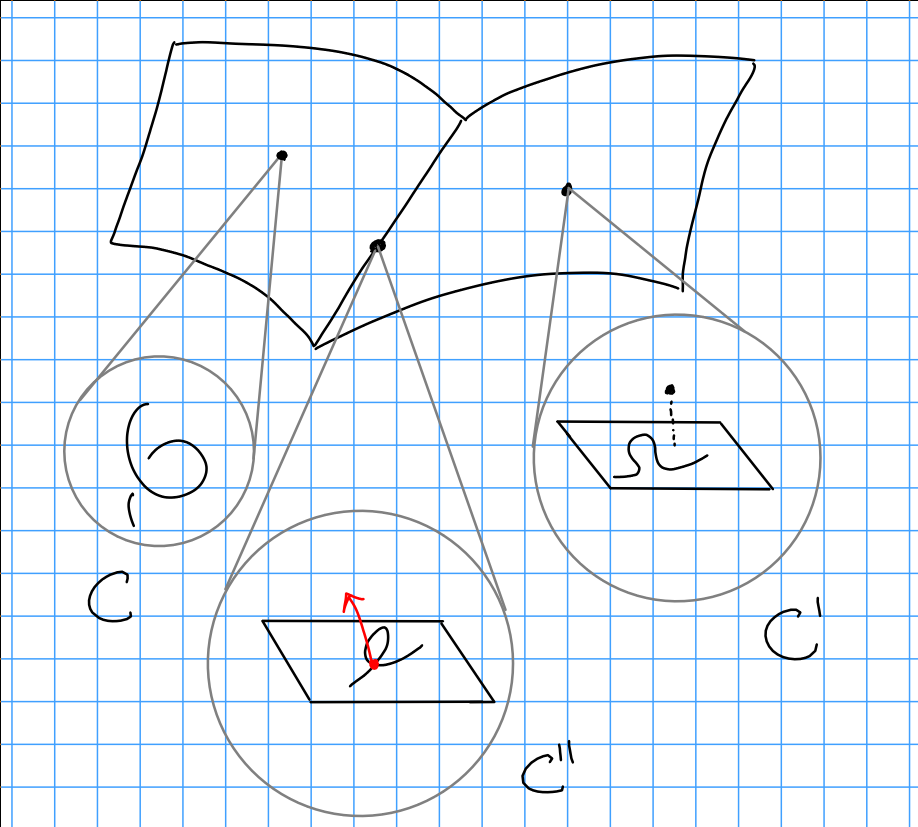

Then $P_{C'} = 1 + \tilde P$, the Hilbert polynomial of just the base without the disjoint point, so this equals $1 + P_{2, 3} = 1 + (3t + 0) = 3t +1$. For $P_{C''}$, we take the sequence
$$\begin{align*}
0 \to k \to {\mathcal{O}}_{C''} \to {\mathcal{O}}_{C'' \text{reduced}} \to 0
,\end{align*}
so
\begin{align*}
P_{C''} = 1 + P_{C'' \text{red}} = 3t+1
.\end{align*}$$

Note that flat families *must* have the same (constant) Hilbert polynomial.

Note that we can get paths in this space from $C\to C''$ and $C'\to C''$ by collapsing a twisted cubic onto a plane, and sending a disjoint point crashing into the node on a nodal cubic. We’re mapping ${\mathbb{P}}^1 \to {\mathbb{P}}^3$, and there is a natural action of $\operatorname{PGL}(4) \curvearrowright{\mathbb{P}}^3$, so we get a map
$$\begin{align*}
\operatorname{PGL}(4) \times{\mathbb{P}}^3 \to {\mathbb{P}}^3
.\end{align*}$$

Let $c\in {\mathbb{P}}^3$ and let ${\mathcal{C}}$ be the preimage. This induces (?) a map
$$\begin{align*}
\operatorname{PGL}(4) \to \operatorname{Hilb}_{{\mathbb{P}}^3}^{3t+1}
\end{align*}
where the fiber over \([C]\) in the latter is \(\operatorname{PGL}(2) = {\operatorname{Aut}}({\mathbb{P}}^1)\). By dimension counting, we find that the dimension of the twisted cubic component is \(15 - 3 = 12\). The 15 in the other component comes from 3-dim choices of plane, 3-dim choices of a disjoint point, and
\begin{align*}
{\mathbb{P}}H^0({\mathbb{P}}^2, {\mathcal{O}}(3))^\vee\cong {\mathbb{P}}^9
,\end{align*}
yielding 15 dimensions. To show that these are actually different components, we use Zariski tangent spaces. Let \(T_1\) be the tangent space of the twisted cubic component, then
\begin{align*}
\dim T_1 \operatorname{Hilb}_{{\mathbb{P}}_k^3}^{3t+1} = 12
,\end{align*}
and similarly the dimension of the tangent space over the \(C'\) component is 15.$$

Let $A$ be Noetherian and local, then the dimension of the Zariski tangent space, $\dim {\mathfrak{m}}/{\mathfrak{m}}^2 \geq \dim A$, the Krull dimension. If this is an equality, then $A$ is regular.

Dimensions of tangent spaces give an upper bound.

If $X_{/k}$ is projective and $P$ is a Hilbert polynomial, then $[Z] \in \operatorname{Hilb}_{X_{/k}}^P$, i.e. a closed subscheme of $X$ with Hilbert polynomial $p$ (note there’s an ample bundle floating around) then the tangent space is $\hom_{{\mathcal{O}}_x}(I_z, {\mathcal{O}}_z)$.

# 6 Hilbert Schemes of Hypersurfaces (Tuesday January 28th)

Last time: Twisted cubics, given by $\operatorname{Hilb}_{{\mathbb{P}}^3_k}^{3t+1}$.

[figure not shown]

> Components of the Scheme of Cubic Curves.

We got lower (?) bounds on the dimension by constructing families, but want an exact dimension. The following will be a key fact:

Let $Z\subset X$ be a closed $k{\hbox{-}}$dimensional subspace. For $[z] \in \operatorname{Hilb}_{X_{_{/k}}}^P(k)$, we have an identification of the Zariski tangent space
$$\begin{align*}
T_{[z]} \operatorname{Hilb}_{X_{_{/k}} }^P = \hom_{{\mathcal{O}}_X}(I_z, {\mathcal{O}}_Z)
\end{align*}$$

Say
$$\begin{align*}
F: ({\operatorname{Sch}}_{_{_{/k}}})^{\operatorname{op}}\to {\operatorname{Set}}
\end{align*}
is a functor and let \(x\in F(k)\). There is an inclusion \(i: \operatorname{Spec}k \hookrightarrow\operatorname{Spec}k[\varepsilon]\) and an induced map$$

$$\begin{align*}
F(\operatorname{Spec}k [\varepsilon]) &\xrightarrow{i^*} F(\operatorname{Spec}k) \\
T_x F \mathrel{\vcenter{:}}=(i^*)^{-1}(x) &\mapsto x
\end{align*}
So if \(F\) is represented by a scheme \(H_{/k}\), then
\begin{align*}
T_x h_J = T_x H = ({\mathfrak{m}}_x / {\mathfrak{m}}_x^2)^\vee\,\,\text{over } k
\end{align*}
Will need a criterion for flatness later, esp. for Artinian thickenings.$$

Assume $A'$ is a Noetherian ring and $0 \to J \to A' \to A \to 0$ with $J^2 = 0$. Assume we have $X'_{/ \operatorname{Spec}A'}$, and a coherent sheaf $F'$ on $X'$, where $X'$ is Noetherian. Then $F'$ is flat over $A'$ iff

1. $F$ is flat
2. $0 \to F\otimes_A J \to F'$ is exact.

[figure not shown]

### 6.0.1 Sketch Proof of Lemma

Take the first exact sequence and tensor with $F'$ (which is right-exact), then $J \otimes_{A'} F' = J \otimes_A$ canonically. This follows because $J = J \otimes_{A'} A$, and there is an isomorphism $J \otimes_{A'} A' \to J \otimes_{A'} A$. And $F = F' \otimes_{A'} A$ is a pullback of $F'$. If flat, then tensoring is exact. Note that both conditions in the lemma are necessary since pullbacks of flats are flat by (1), and (2) gives the flatness condition.

Recall that for a module over a Noetherian ring, $M/A$, $M$ is **flat** over $A$ iff
$$\begin{align*}
\operatorname{Tor}_1^A(M, A/p) = 0 &&
\text{ for all primes } p
.\end{align*}$$

Reason: Tor commutes with direct limits, so $M$ is flat iff

$$\begin{align*}
\operatorname{Tor}_1^A(M, N) = 0
&& \text{for all finitely generated } N
.\end{align*}$$

Since $A$ is Noetherian, $N$ has a finite filtration $N^\cdot$ where $N_i / N_{i+1} \cong A/p_i$. Use the fact that every ideal is contained in a prime ideal. Take $x\in N$, this yields a map $A\to N$ which factors through $A/I$. If we make such a filtration on $A/I$, then we can quotient $N$ by $\operatorname{im}f$ where $f: A/I \to N$. Continuing inductively, the resulting filtration must stabilize. So we can assume $N = A/I$. Then $I$ is contained in a maximal.

Finish proof. See Aatiyah Macdonald.

### 6.0.2 Proof of Proposition

So it’s enough to show that $\operatorname{Tor}_1^{A'}(F', A'/p') = 0$ for all primes $p' \subset A'$.

Since $J$ is nilpotent, $J \subset p'$.

## 6.1 Consequences of Proof

Let $p = p'/J$, this is a prime ideal. We have an exact diagram by taking quotients:

[figure not shown]

So we can tensor with $F'$ everywhere, and get a map from kernels to cokernels using the snake lemma:

[figure not shown]

Then by (1), we have
$$\begin{align*}
\operatorname{Tor}_1^{A'}(A'/p', F') = \operatorname{Tor}_1^{A'}(A/p, F') = 0
.\end{align*}$$

We will just need this for $A' = k[\varepsilon]$ and $A=k$.

$$\begin{align*}
T_z \operatorname{Hilb}_{X_{_{/k}}} = \hom_{{\mathcal{O}}_x}(I_z, {\mathcal{O}}_z)
.\end{align*}$$

Again we have $T_z \operatorname{Hilb}_{X_{_{/k}}} \subset \operatorname{Hilb}_{X_{_{/k}}}(k[\varepsilon])$, and is given by
$$\begin{align*}
\left\{{Z' \subset X \times_{\operatorname{Spec}k} \operatorname{Spec}k[\varepsilon]
{~\mathrel{\Big|}~}Z' \text{ is flat}_{/k[\varepsilon]},\,\, Z' \times_{\operatorname{Spec}k[\varepsilon]}\operatorname{Spec}k = Z}\right\}
.\end{align*}$$

We have an exact diagram:

[figure not shown]

Note the existence of a splitting above. Given $\phi \in \hom_{{\mathcal{O}}_x}(I_Z, {\mathcal{O}}_Z)$. We have
$$\begin{align*}
I_{Z'} = \left\{
f + \varepsilon g \,
\middle\vert
\,
\begin{array}{ll}
f,g &\in I_Z, \\
\phi(f) &= g\pmod I_Z, \\
\phi(f) &\in {\mathcal{O}}_Z, \\
g\pmod I_Z &\in {\mathcal{O}}_x/I_Z = {\mathcal{O}}_Z
\end{array}
\right\}
.\end{align*}$$

It’s easy to see that $Z' \subset x'$, and

1. $Z'\times k = Z$
2. It’s flat over $k[\varepsilon]$, looking at $0 \to k\otimes I_{Z'} \to I_{Z'}$.

For the converse, take $f\in I_Z$ and lift to $f' = f + \varepsilon g \in I_{Z'}$, then $g\in {\mathcal{O}}_x$ is well-defined wrt $I_Z$. Then $g\in \hom_{{\mathcal{O}}_x}(I_z, {\mathcal{O}}_z)$.

The main point here is that these hom sets are extremely computable.

Let $Z$ be a twisted cubic in $\operatorname{Hilb}_{{\mathbb{P}}^3_{/k}}^{3t+1}(k)$.

$$\begin{align*}
\hom_{{\mathcal{O}}_x}(I_Z, {\mathcal{O}}_Z) = \hom_{{\mathcal{O}}_X}(I_Z/I_Z^2, {\mathcal{O}}_Z) = \hom_{{\mathcal{O}}_Z}(I_Z/I_Z^2, {\mathcal{O}}_Z)
\end{align*}$$

If $I_Z/I_Z^2$ is locally free, these are global sections of the dual, i.e. $H^0((I_Z/I_Z^2)^\vee)$. In this case, $Z\hookrightarrow X$ is regularly embedded, and thus $(I_Z/I_Z^2)^\vee$ should be regarded as the normal bundle. Sections of the normal bundle match up with directions to take first-order deformations:

[figure not shown]

For $i:C \hookrightarrow{\mathbb{P}}^3$, there is an exact sequence
$$\begin{align*}
0 \to I/I^2 \to &i^* \Omega_{{\mathbb{P}}^3} \to \Omega_\varepsilon\to 0 \\
&\Downarrow \quad \text{ taking duals } \\
0 \to T_C \to &i^* T_{{\mathbb{P}}^3} \to N_{C_{/{\mathbb{P}}^3} } \to 0
,\end{align*}
How do we compute \(T_{{\mathbb{P}}^3}\)? Fit into the exact sequence
\begin{align*}
0 \to {\mathcal{O}}\to i^* {\mathcal{O}}(1)^4 \to i^* T_{{\mathbb{P}}^3} \to 0
,\end{align*}
which we can restrict to \(C\).$$

We have $i^* {\mathcal{O}}(1) \cong {\mathcal{O}}_{{\mathbb{P}}^1}(3)$, so
$$\begin{align*}
0 \to H^0 {\mathcal{O}}_c \to &H^*({\mathcal{O}}(3)^4) \to H^0(i^* T_{{\mathbb{P}}^3}) \to 0 \\
&\Downarrow \\
0\to k \to &k^{16} \to k^{15} \to 0
.\end{align*}$$

This yields
$$\begin{align*}
0 \to H^0(T_c) \to &H^0(i^* T_{{\mathbb{P}}^3}) \to H^0(N_{C_{ /{\mathbb{P}}^3} }) \to H^1 T_c \\
&\Downarrow \\
0\to k^3 \to &k^{15} \to k^{12} \to 0
\end{align*}$$

We can identify
$$\begin{align*}
\hom(I_Z,{\mathcal{O}}_Z) = H^0( (I_Z/I_Z^2)^\vee) = H^0({\mathcal{O}}_Z(d))
.\end{align*}$$

[figure not shown]

The tangent space of the following cubic:

[figure not shown]

We can identify
$$\begin{align*}
\hom_{{\mathcal{O}}_k}(I_Z, {\mathcal{O}}_Z) = H^0((I_Z/I_Z^2)^\vee) = 3 + H^0((I_{Z_0}/I_{Z_0}^2)^\vee)
,\end{align*}$$

where the latter equals $H^0 \qty{ {\mathcal{O}}_1\mathrel{\Big|}_{z_0} \oplus {\mathcal{O}}(\zeta)\mathrel{\Big|}_{z_0} }$ yielding
$$\begin{align*}
3+9 = 12
.\end{align*}$$

# 7 Uniform Vanishing Statements (Thursday January 30th)

Recall how we constructed the Hilbert scheme of hypersurfaces
$$\begin{align*}
\operatorname{Hilb}_{{\mathbb{P}}_k^n}^{P_{m, d}} = {\mathbb{P}}H^0({\mathbb{P}}^n; {\mathcal{O}}(d))^\vee
\end{align*}
A section \(\operatorname{Hilb}_{{\mathbb{P}}_k^n}^{P}(s)\) corresponds to \(z\in {\mathbb{P}}^n_s\). We can look at the exact sequence$$

$$\begin{align*}
0 \to I_Z(m) \to {\mathcal{O}}_{{\mathbb{P}}_S^n} \xrightarrow{\text{restrict}} {\mathcal{O}}_z(m) \to 0
.\end{align*}$$

as ${\mathbb{P}}_s^n \xrightarrow{\pi_s} S$, so we can pushforward along $\pi$, which is left-exact, so

$$\begin{align*}
0 \to \pi_{s*} I_Z(m) \to \pi_{s*} {\mathcal{O}}_{{\mathbb{P}}_S^n} = {\mathcal{O}}_S \otimes H^0({\mathbb{P}}^n; {\mathcal{O}}(m)) \to {\mathcal{O}}_z(m) \to R^1 \pi_{s*} I_Z(m) \to \cdots
.\end{align*}$$

*Idea:* $Z \subset {\mathbb{P}}_k^n$ will be determined (in families!) by the space of degree $d$ polynomials vanishing on $Z$ (?), i.e.
$$\begin{align*}
H^0({\mathbb{P}}^n, I_z(m)) \subset H^0({\mathbb{P}}^n, {\mathcal{O}}(m))
\end{align*}
for \(m\) very large. This would give a map of functors
\begin{align*}
\operatorname{Hilb}_{{\mathbb{P}}_k^n}^{P} \to {\operatorname{Gr}}(N, H^0({\mathbb{P}}^n, {\mathcal{O}}(m) ))
.\end{align*}
If this is a closed subfunctor, a closed subfunctor of a representable functor is representable and we’re done .$$

We need to get an $m$ uniform in $Z$, and more concretely:

1. First need to make sense of what it means for $Z$ to be determined by $H^0({\mathbb{P}}^n, I_Z(m))$ for $m$ only depending on $P$.
2. This works point by point, but we need to do this in families. I.e. we’ll use the previous exact sequence, and want the $R^1$ to vanish.

We need *uniform* vanishing statements. There is a convenient way to package the vanishing requirements needed here. From now on, take $k=\mkern 1.5mu\overline{\mkern-1.5muk\mkern-1.5mu}\mkern 1.5mu$ and ${\mathbb{P}}^n = {\mathbb{P}}_k^n$.

## 7.1 $m{\hbox{-}}$Regularity

A coherent sheaf $F$ on ${\mathbb{P}}^n$ is **$m{\hbox{-}}$regular** if $H^i({\mathbb{P}}^n; F(m-i)) = 0$ for all $i> 0$.

Consider ${\mathcal{O}}_{{\mathbb{P}}^n}$, this is $0{\hbox{-}}$regular. Line bundles on ${\mathbb{P}}_n$ only have 0 and top cohomology. Just need to check that $H^n({\mathbb{P}}^n; {\mathcal{O}}(-n)) = 0$, but by Serre duality this is
$$\begin{align*}
H^0({\mathbb{P}}^n; {\mathcal{O}}(n) \otimes\omega_{{\mathbb{P}}^n})^\vee= H^0({\mathbb{P}}^n; {\mathcal{O}}(-1))^\vee= 0
.\end{align*}$$

Assume $F$ is $m{\hbox{-}}$regular. Then

${\mathcal{O}}$ is $m{\hbox{-}}$regular for $m \geq 0$ implies ${\mathcal{O}}(k)$ is $-k{\hbox{-}}$regular and is also $m{\hbox{-}}$regular for$m\geq -k$.

### 7.1.1 Proof of 2 and 3

Induction on dimension of $n$ in ${\mathbb{P}}^n$. Coherent sheaves on ${\mathbb{P}}^0$ are vector spaces, so no higher cohomology.

Take a generic hyperplane $H \subset {\mathbb{P}}^n$, there is an exact sequence
$$\begin{align*}
0 \to {\mathcal{O}}(-1) \to {\mathcal{O}}\to {\mathcal{O}}_H \to 0
.\end{align*}$$

where ${\mathcal{O}}_H$ is the structure sheaf. Tensoring with $H$ remains exact, so we get
$$\begin{align*}
0 \to F(-1) \to F \to F_H \to 0
.\end{align*}$$

Why? ${\mathbb{A}}^n \subset {\mathbb{P}}^n$, let $A = {\mathcal{O}}_{{\mathbb{P}}^n}({\mathbb{A}}^n)$ be the polynomial ring over ${\mathbb{A}}^n$. Then the restriction of the first sequence to ${\mathbb{A}}^n$ yields
$$\begin{align*}
0 \to A \xrightarrow{f} A \to A/f \to 0
,\end{align*}
and thus we want
\begin{align*}
F \xrightarrow{f} F \to F/fF \to 0
\end{align*}
which results after restricting the second sequence to \({\mathbb{A}}^n\). Thus we just want \(f\) to not be a zero divisor. If we take \(f\) not vanishing on any associated point of \(F\), then this will be exact. Associated points: generic points arising by supports of sections of \(F\). \(F\) is coherent, so it has finitely many associated points. If \(H\) does not contain any of the associated points of \(F\), then the second sequence is indeed exact.$$

Twist up by $k$ to obtain
$$\begin{align*}
0 \to F(k-1) \to F(k) \to F_H(k) \to 0
.\end{align*}
Look at the LES in cohomology to get
\begin{align*}
H^i(F(m-i)) \to H^i(F_H(m-i)) \to H^{i+1}(F(m - (i+1)))
.\end{align*}
So \(F_H\) is \(m{\hbox{-}}\)regular. By induction, this proves statements 1 and 2 for all \(F_H\). So take \(k = m+1-i\) and consider
\begin{align*}
H^i(F(m-i)) \to H^i(F(m+1-i)) \to H^i(F_H(m+1-i))
.\end{align*}
We know 2 is satisfied, so the RHS is zero, and we know the LHS is zero, so the middle term is zero. Thus \(F\) itself is \(m+1\) regular, and by inducting on \(m\) we get statement 2.$$

By multiplication maps, we get a commutative diagram:

[figure not shown]

We’d like to show the diagonal map is surjective.

1. The top map is a surjection, since
   $$\begin{align*}
   H^0(F(k)) \to H^0(F_H(k)) \to H^1(F(k-1)) = 0
   \end{align*}
   for \(k\geq m\) by (2).$$
2. The right-hand map is surjective for $k\geq m$.
3. $\ker(\alpha) \subset \operatorname{im}(\beta)$ by a small diagram chase, so $\beta$ is surjective.

This shows (1) and (2) completely.

We know $F(k)$ is globally generated for $k\gg 0$. Thus for all $k\geq m$, $F(k)$ is globally generated by (1).

Let $P \in {\mathbb{Q}}[t]$ be a Hilbert polynomial. There exists an $m_0$ only depending on $P$ such that for all subschemes $Z \subset {\mathbb{P}}^n_k$ with Hilbert polynomial $P_Z = P$, the ideal sheaf $I_z$ is $m_0{\hbox{-}}$regular.

### 7.1.2 Proof of Theorem

Induct on $n$. For $n=0$, again clear because higher cohomology vanishes and there are no nontrivial subschemes. For a fixed $Z$, pick $H$ in ${\mathbb{P}}^n$ (and setting $I \mathrel{\vcenter{:}}= I_z$ for notation) such that
$$\begin{align*}
0 \to I(-1) \to I \to I_H \to 0
.\end{align*}
is exact. Note that the Hilbert polynomial \(P_{I_H}(t) = P_I(t) - P_I(t-1)\) and \(P_I = P_{{\mathcal{O}}_{{\mathbb{P}}^n}} - P_Z\). By induction, there exists some \(m_1\) depending only on \(P\) such that \(I_H\) is \(m_1{\hbox{-}}\)regular. We get
\begin{align*}
H^{i-1}(I_H(k)) \to H^i(I(k-1)) \to H^i(I(k)) \to H^i(I_H(k))
,\end{align*}
and for \(k\geq m_1 - i\) the LHS and RHS vanish so we get an isomorphism in the middle. By Serre vanishing, for \(k \gg 0\) we have \(H^i(I(k)) = 0\) and thus \(H^i(I(k)) = 0\) for \(k\geq m_i - i\). This works for all \(i > 1\), we have \(H^i(I(m_i - i)) = 0\). We now need to find \(m_0 \geq m_1\) such that \(H^1(I(m_0 - 1)) = 0\) (trickiest part of the proof).$$

The sequence $\qty{\dim H^1(I(k))}_{k\geq m_i - 1}$ is *strictly* decreasing.[^4]

Given the lemma, it’s enough to take $m_0 \geq m_1 + h^1(I(m_1 - 1))$. Consider the LES we have a surjection
$$\begin{align*}
H^0({\mathcal{O}}_Z(m_1 - 1)) \to H^1(I(m_1 - 1)) \to 0
.\end{align*}
So the dimension of the LHS is equal to \(P_Z(m_1 - 1)\), using the fact that terms vanish and make the Euler characteristic equal to \(P_Z\). Thus we can take \(m_0 = m_1 + P(m_1 - 1)\).$$

Considering the LES
$$\begin{align*}
H^0(I(k+1)) \xrightarrow{\alpha_{k+1}} H^0(I_H(k+1)) \to H^1(I(k)) \to H^1(I(k+1)) \to 0
,\end{align*}
where the last term is zero because \(I_H\) is \(m_1{\hbox{-}}\)regular. So the sequence \(h^1(I(k))\) is non-increasing.$$

If it does *not* strictly decrease for some $k$, then there is an equality on the RHS, which makes $\alpha_{k+1}$ surjective. This means that $\alpha_{k+2}$ is surjective, since
$$\begin{align*}
H^0({\mathcal{O}}(1)) \otimes H^0(I_H(k+1)) \twoheadrightarrow H^0(I_H(k+2))
.\end{align*}$$

So if one is surjective, everything above it is surjective, but by Serre vanishing we eventually get zeros. So $\alpha_{k+i}$ is surjective for all $i\geq 1$, contradicting Serre vanishing, since the RHS are isomorphisms for all $k$.

Thus for any $Z\subset {\mathbb{P}}^n_k$ with $P_Z = P$, we uniformly know that $I_Z$ is $m_0{\hbox{-}}$regular for some $m_0$ depending only on $P$.

It is determined by these polynomials because we have a sequence
$$\begin{align*}
0 \to I_Z(m_0) \to {\mathcal{O}}(m_0) \to {\mathcal{O}}_Z(m_0) \to 0
.\end{align*}$$

We can get a commuting diagram over it
$$\begin{align*}
0 \to H^0(I_Z(m_0)) \otimes{\mathcal{O}}_{{\mathbb{P}}^n} \to H^0({\mathcal{O}}(m_0)) \otimes{\mathcal{O}}_{{\mathbb{P}}^n} \to \cdots
\end{align*}
where the middle map down is just evaluation and.the first map down is a surjection. Hence \(I_Z(m_0)\), hence \({\mathcal{O}}_Z\), hence \(Z\) is determined by \(H^0(I_Z(m_0))\).$$

> Next time: we’ll show that this is a subfunctor that is locally closed.

# 8 Thursday February 6th

> Review base-change!

For $k=\mkern 1.5mu\overline{\mkern-1.5muk\mkern-1.5mu}\mkern 1.5mu$, and $C_{/k}$ a smooth projective curve, then $\operatorname{Hilb}_{C_{/k}}^n = \operatorname{Sym}^n C$.

For $X_{_{/k}}$ a smooth projective *surface*, $\operatorname{Hilb}_{X_{_{/k}}}^n \neq \operatorname{Sym}^n X$, there is a map (the Hilbert-Chow map)
$$\begin{align*}
\operatorname{Hilb}_{X_{_{/k}}}^n &\to \operatorname{Sym}^n X \\
Z &\mapsto {\operatorname{supp}}(Z) \\
U = \text{reduced subschemes} &\mapsto U' = \text{ reduced multisets } \\
{\mathbb{P}}^1 &\mapsto (x, x)
.\end{align*}$$

Consider ${\mathbb{A}}^2 \times{\mathbb{A}}^2$ under the ${\mathbb{Z}}/2{\mathbb{Z}}$ action
$$\begin{align*}
( (x_1, y_1), (x_2, y_2)) \mapsto ((x_2, y_2), (x_1, y_1))
.\end{align*}$$

Then
$$\begin{align*}
({\mathbb{A}}^2)^2 / {\mathbb{Z}}/2{\mathbb{Z}}
&= \operatorname{Spec}k[x_1, y_1, x_2, y_2]^{{\mathbb{Z}}/2{\mathbb{Z}}} \\
&= \operatorname{Spec}k[x_1 x_2, y_1 y_2, x_1 + x_2, y_1 + y_2, x_1 y_2 + x_2 y_1, \cdots]
\end{align*}
with a bunch of symmetric polynomials adjoined.$$

Take ${\mathbb{A}}^2$ and consider $\operatorname{Hilb}_{{\mathbb{P}}^2}^3$. If $I$ is a monomial ideal in ${\mathbb{A}}^2$, there is a nice picture. We can identify the tangent space
$$\begin{align*}
T_Z \operatorname{Hilb}_{{\mathbb{P}}^2}^n = \hom_{{\mathcal{O}}_{{\mathbb{P}}^2}} ( I_2, {\mathcal{O}}_Z) = \bigoplus \hom(I_{Z_i}, {\mathcal{O}}_{Z_i})
.\end{align*}
if \(Z = {\coprod}Z_i\). If \(I\) is supported at 0, then we can identify the ideal with the generators it leaves out.$$

$I = (x^2, xy, y^2)$:

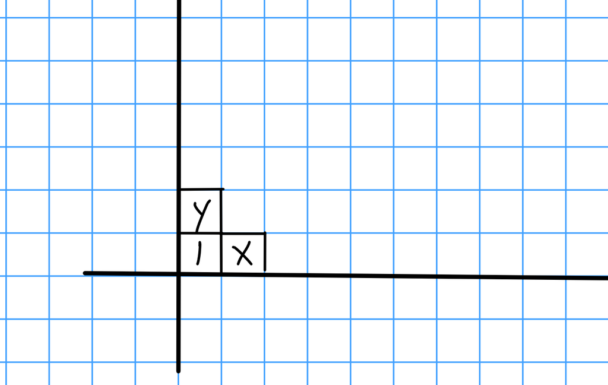

Image

$I = (x^6, x^2y^2, xy^4, y^5)$:

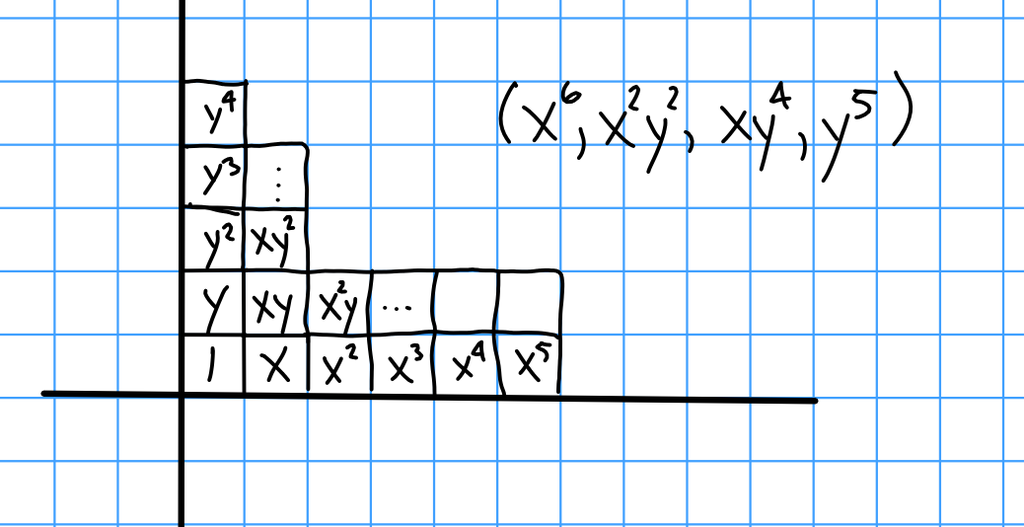

Image

$I = (x^2, y)$. Let $e=x^2, f = y$.

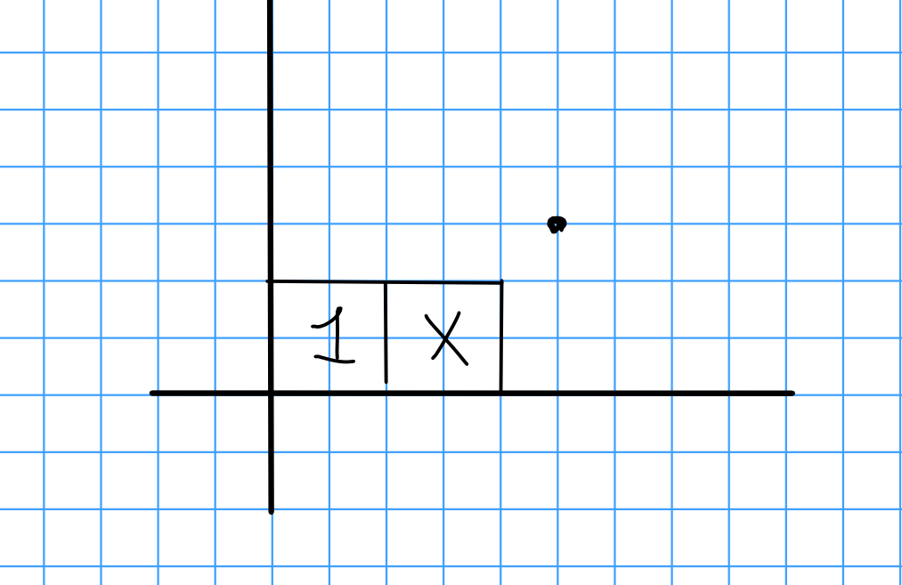

Image

By comparing rows to columns, we obtain a relation $ye = x^2 f$. Write ${\mathcal{O}}= \left\{{1, x}\right\}$, then note that this relation is trivial in ${\mathcal{O}}$ since $y=x^2=0$. Thus $\hom(I, {\mathcal{O}}) = \hom(k^2, k^2)$ is 4-dimensional.

Note that $C_{_{/k}}$ for curves is an important case to know. Take $Z \subset C \times C^n$, then quotient by the symmetric group $S^n$ (need to show this can be done), then $Z/S^n \subset C \times\operatorname{Sym}^n C$ and composing with the functor $\operatorname{Hilb}$ represents yields a map $\operatorname{Sym}^n C \to \operatorname{Hilb}_{C_{/k}}^n$. This is bijective on points, and a tangent space computation shows it’s an isomorphism.

Consider the nodal cubic in ${\mathbb{P}}^2$:

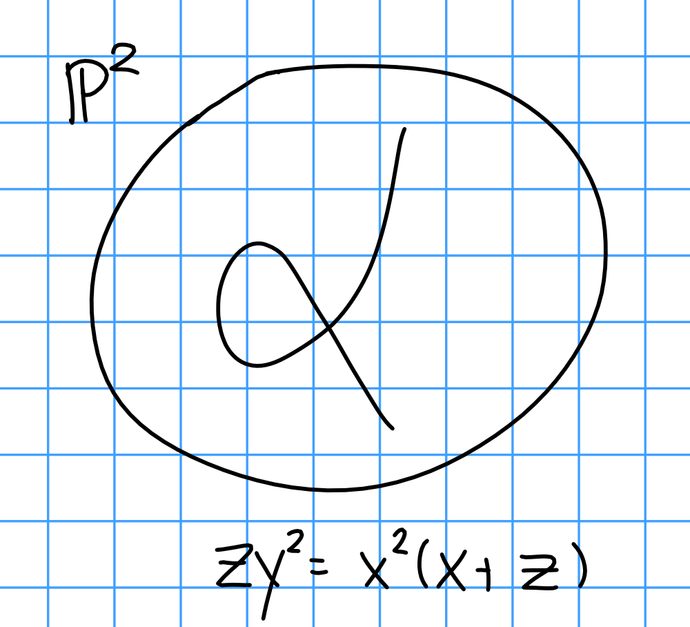

Nodal cubic

> The nodal cubic $zy^2 = x^2(x+z)$.

Consider the open subscheme $V \subset \operatorname{Hilb}_{C_{/k}}^2$ of points $z \subset U$ for $U \subset C$ open. We can normalize:

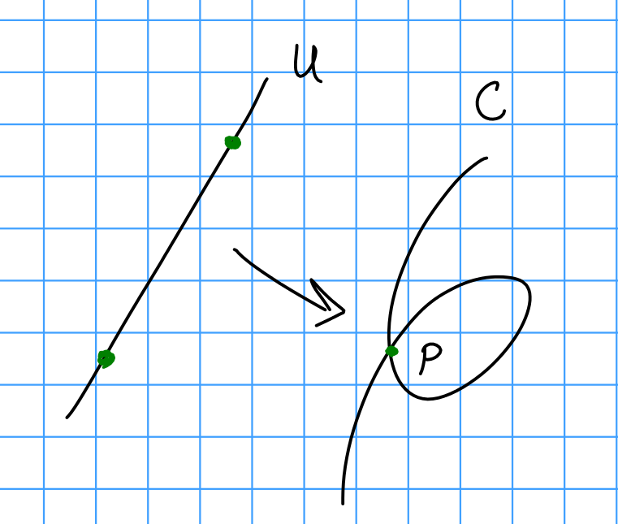

Normalized cubic

This yields a map fro ${\mathbb{P}}^1 \setminus\text{2 points}$. This gives us a stratification, i.e. a locally closed embedding
$$\begin{align*}
(\text{z supported on U}) {\coprod}(\text{1 point at p}) {\coprod}(\text{both points at p}) \to \operatorname{Hilb}_{C_{/k}}^2
.\end{align*}$$

The first locus is given by the complement of two lines:

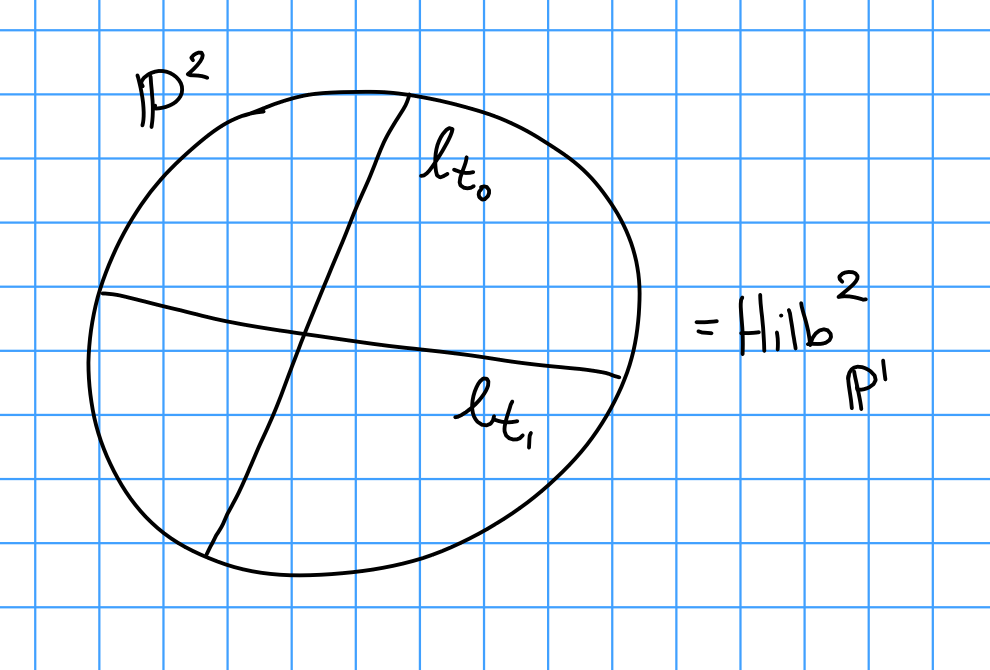

Locus 1

The third locus is given by arrows at $p$ pointing in any direction, which gives a copy of ${\mathbb{P}}^1$. The second is ${\mathbb{P}}^1$ minus two points. Above each point is a nodal cubic with two marked points, and moving the base point towards a line correspond to moving one of the points toward the node:

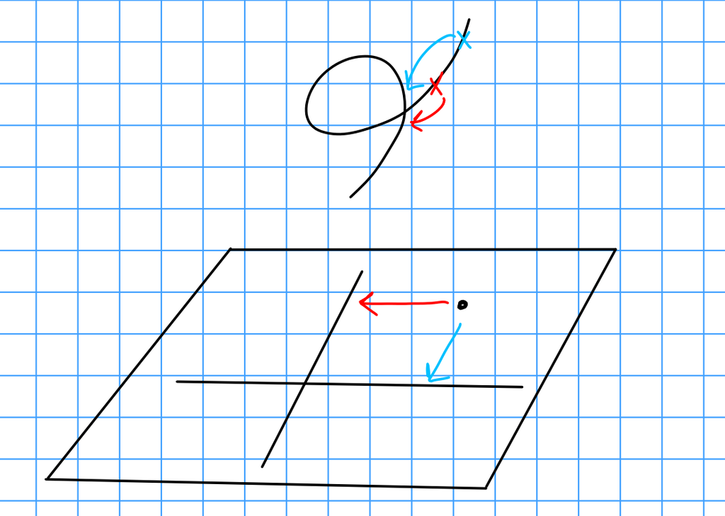

Moving base toward the point

More precisely, we’re considering the cover ${\mathbb{P}}^1 \setminus\text{2 points} \to C$ and thinking about ways in which two points and approach the missing points. These give specific tangent directions at the node on the cubic, depending on how this approach happens – either both points approach missing point #1, both approach missing point #2, or each approach a separate missing point.

Useful example to think about. Not normal, reduced, but glued in a weird way. Possibly easier to think about: cuspidal cubic.

## 8.1 Representability

Recall the following definition:

A coherent sheaf $F$ on ${\mathbb{P}}_k^n$ for $k$ a field is $m{\hbox{-}}$regular iff $H^i(F(m-i)) = 0$ for all $i> 0$.

For every Hilbert polynomial $P$, there exists some $m_0$ depending on $P$ such that any $Z \subset {\mathbb{P}}^n_k$ with $P_Z = P$ satisfies $I_Z$ is $m{\hbox{-}}$regular.

$F$ is $m{\hbox{-}}$ regular iff $\mkern 1.5mu\overline{\mkern-1.5muF\mkern-1.5mu}\mkern 1.5mu = F \times_{\operatorname{Spec}k} \operatorname{Spec}\mkern 1.5mu\overline{\mkern-1.5muk\mkern-1.5mu}\mkern 1.5mu$ is $m{\hbox{-}}$regular.

The $m_0$ produced does not depend on $k$.

For $m_0 = m_0(P)$ and $N = N(P)$, we have an embedding as a subfunctor
$$\begin{align*}
\operatorname{Hilb}_{{\mathbb{P}}^m_{\mathbb{Z}}}^P \to {\operatorname{Gr}}(N, H^0( {\mathbb{P}}^n_{\mathbb{Z}}, {\mathcal{O}}(m_0) )^\vee)
.\end{align*}$$

For any $Z \subset {\mathbb{P}}^n_S$ flat over $S$ with $P_{Z_s} = P$ for all $s\in S$ points, we want to send this to
$$\begin{align*}
0\to R^\vee\to {\mathcal{O}}_s \otimes H^0({\mathbb{P}}^n_{\mathbb{Z}}, {\mathcal{O}}(m_0))^\vee\to Q \to 0
\end{align*}
or equivalently
\begin{align*}
0 \to Q^\vee\to {\mathcal{O}}_s \otimes H^0({\mathbb{P}}^n_{\mathbb{Z}}, {\mathcal{O}}(m_0)) \to R \to 0
\end{align*}
with \(R\) locally free.$$

So instead of the quotient $Q$ being locally free, we can ask for the sub $Q^\vee$ to be locally free instead, which is a weaker condition.

We thus send $Z$ to
$$\begin{align*}
0 \to \pi_{s*} I_Z(m_0) \to \pi_{s*} {\mathcal{O}}_{{\mathbb{P}}^n_s}(m_0) = {\mathcal{O}}_s \otimes H^0({\mathbb{P}}^n, {\mathcal{O}}(m_0))
\end{align*}
which we obtain by taking the pushforward from this square:$$

[figure not shown]

We have a sequence $0 \to I_Z(m_0) \to {\mathcal{O}}(m_0) \to {\mathcal{O}}_Z(m_0) \to 0$. Thus we get a sequence

$$\begin{align*}
0 \to \pi_{s*}I_Z(m_0) \to \pi_{s*}{\mathcal{O}}(m_o) \to \pi_{s*} {\mathcal{O}}_Z(m_0) \to R^1 \pi_{s*}I_Z(m_0) \to \cdots
.\end{align*}$$

### 8.1.1 Step 1

$$\begin{align*}
R^1\pi_* I_Z(m_0) = 0
.\end{align*}$$

By base change, it’s enough to show that $H^1(Z_s, I_{Z_s}(m_0)) = 0$. This follows by $m_0{\hbox{-}}$regularity.

### 8.1.2 Step 2

$\pi_{s*}I_Z(m_0)$ and $\pi_{s*} {\mathcal{O}}_Z(m_0)$ are locally free. For all $i>0$, we have

- $R^i \pi_{s*} I_Z(m_0) = 0$ by $m_0{\hbox{-}}$regularity,
- $R^i \pi_{s*} {\mathcal{O}}(m_0) = 0$ by base change,
- and thus $R^i \pi_{s*} {\mathcal{O}}_Z(m_0) = 0$.

### 8.1.3 Step 3

$\pi_{s*}I_Z(m_0)$ has rank $N = N(P)$.

Again by base change, there is a map $\pi_* I_Z(m_0) \otimes k(s) \to H^0(Z_S, I_{Z_s}(m_0))$ which we know is an isomorphism. Because $h^i ( I_{Z_S}(m_0) ) = 0$ for $i>0$ by $m{\hbox{-}}$regularity and
$$\begin{align*}
h^0(I_{Z_S}(m_0)) = P_{\mathcal{O}}(m_0) - P_{{\mathcal{O}}_{Z_s}}(m_0) = P_{\mathcal{O}}(m_0) - P(m_0)
.\end{align*}$$

This yields a well-defined functor
$$\begin{align*}
\operatorname{Hilb}_{{\mathbb{P}}^n_{\mathbb{Z}}}^P \to {\operatorname{Gr}}(N, H^0({\mathbb{P}}^n, {\mathcal{O}}(m_0))^\vee)
.\end{align*}$$

Note that we’ve just said what happens to objects; strictly speaking we should define what happens for morphisms, but they’re always give by pullback.

We want to show injectivity, i.e. that we can recover $Z$ from the data of a number f polynomials vanishing on it, which is the data $0 \to \pi_{s*} I_Z(m_0) \to {\mathcal{O}}_s \otimes H^0({\mathbb{P}}^n, {\mathcal{O}}(m_0))$.

Given
$$\begin{align*}
0 \to Q^\vee\to {\mathcal{O}}_s \otimes H^0({\mathbb{P}}^n, {\mathcal{O}}(m_0)) = \pi_{s*} {\mathcal{O}}_{{\mathbb{P}}^n_S}(m_0)
\end{align*}
we get a diagram$$

[figure not shown]

where $Q^\vee= \pi_{s*} I_Z(m_0)$, so we’re looking at

[figure not shown]

The surjectivity here follows from ${\mathcal{O}}_{Z_s} \otimes H^0(I_{Z_s}(m_0)) \to I_{Z_s}(m_0)$ (?). Given a universal family $G = {\operatorname{Gr}}( N, H^0({\mathcal{O}}(m_0))^\vee)$ and $Q^\vee\subset {\mathcal{O}}_G \otimes H^0({\mathcal{O}}(m_0))^\vee$, we obtain $I_W \subset {\mathcal{O}}_G$ and $W \subset {\mathbb{P}}^n_G$.

# 9 Tuesday February 18th

Let $X/S$ be a projective subscheme (i.e. $X\subset {\mathbb{P}}^n$ for some $n$). The Hilbert functor of flat families $\operatorname{Hilb}_{X/S}^p$ is representable by a projective $S{\hbox{-}}$scheme.

Note that without a fixed $P$, this is *locally* of finite type but not finite type. After fixing $P$, it becomes finite type.

For a curve of genus $g$, there is a smooth family ${\mathcal{C}}\xrightarrow{\pi} S$ with $S$ finite-type over ${\mathbb{Z}}$ where every genus $g$ curve appears as a fiber. I.e., genus $g$ curves form a *bounded family* (here there are only finitely many algebraic parameters to specify a curve). How did we construct? Take the third power of the canonical bundle and show it’s very ample, so it embeds into some projective space and has a Hilbert polynomial.

In fact, there is a finite type *moduli stack* ${\mathcal{M}}_g / {\mathbb{Z}}$ of genus $g$ curves. There will be a map $S \twoheadrightarrow{\mathcal{M}}_g$, noting that ${\mathcal{C}}$ is not a moduli space since it may have redundancy. We’ll use the fact that a finite-type scheme surjects onto ${\mathcal{M}}_g$ to show it is finite type.

If $X/S$ is proper, we can’t talk about the Hilbert polynomial, but the functor $\operatorname{Hilb}_{X/S}$ is still representable by a locally finite-type scheme with connected components which are proper over $S$.

If $X/S$ is *quasiprojective* (so locally closed, i.e. $X\hookrightarrow{\mathbb{P}}^n_S$), then $\operatorname{Hilb}_{X/S}^P(T) \mathrel{\vcenter{:}}=\left\{{z\in X_T \text{ projective, flat over S with fiberwise Hilbert polynomial P }}\right\}$ is still representable, but now by a quasiprojective scheme.

Length $Z$ subschemes of ${\mathbb{A}}^1$: representable by ${\mathbb{A}}^2$.

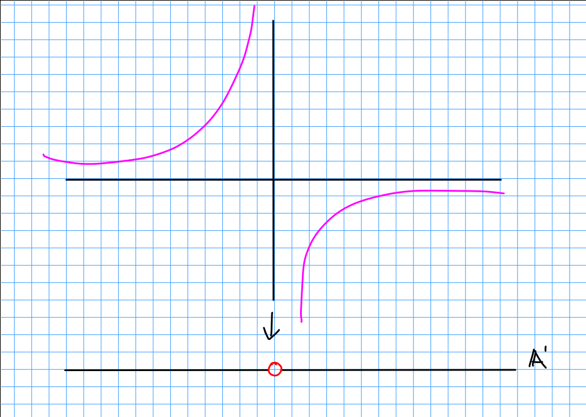

Upstairs: parametrizing length 1 subschemes, i.e. points.

If $X\subset {\mathbb{P}}_S^n$ and $E$ is a coherent sheaf on $X$, then
$$\begin{align*}
\operatorname{Quot}_{E, X/S}^{P}(T) = \left\{{ j^*E \to F \to 0, \text{ over } X_T \to T,~F \text{ flat with fiberwise Hilbert polynomial } P }\right\}
\end{align*}
where \(T \xrightarrow{g} S\) is representable by an \(S{\hbox{-}}\)projective scheme.$$

Take $E = {\mathcal{O}}_x$, $X$ and $S$ a point, and $E$ is a vector space, then $\operatorname{Quot}_{E/S}^P = {\operatorname{Gr}}(\operatorname{rank}, E)$.

The Hilbert scheme of 2 points on a surface is more complicated than just the symmetric product.

$$\begin{align*}
\qty{{\mathbb{A}}^2}^3 &\to \qty{{\mathbb{A}}^2}^2 \\
\supseteq \Delta\mathrel{\vcenter{:}}=\Delta_{01} \times\Delta_{02} &\to \qty{{\mathbb{A}}^2}^2
\end{align*}$$

where $\Delta_{ij}$ denote the diagonals on the $i, j$ factors. Here all associate points of $\Delta$ dominate the image, but it is not flat. Note that if we take the complement of the diagonal in the image, then the restriction $\Delta' \to \qty{{\mathbb{A}}^2}^2\setminus D$ is in fact flat.

The Hilbert scheme may have nontrivial scheme structure, i.e. this will be a “nice” Hilbert scheme with is generally not reduced. We will find a component $H$ of a $\operatorname{Hilb}_{{\mathbb{P}}^3_C}^P$ whose generic point corresponds to a smooth irreducible $C\subset {\mathbb{P}}^3$ which is generically non-reduced.

## 9.1 Cubic Surfaces

> See Hartshorne Chapter 5.

Let $X\subset {\mathbb{P}}^3$ be a smooth cubic surface, then ${\mathcal{O}}(1)$ on ${\mathbb{P}}^3$ restricts to a divisor class $H$ of a hyperplane section, i.e. the associated line bundle ${\mathcal{O}}_x(H) = {\mathcal{O}}_x(1)$.

$X$ is the blowup of ${\mathbb{P}}^2$ minus 6 points (replace each point with a curve). There is thus a blowdown map $X \xrightarrow{\pi} {\mathbb{P}}^2$.

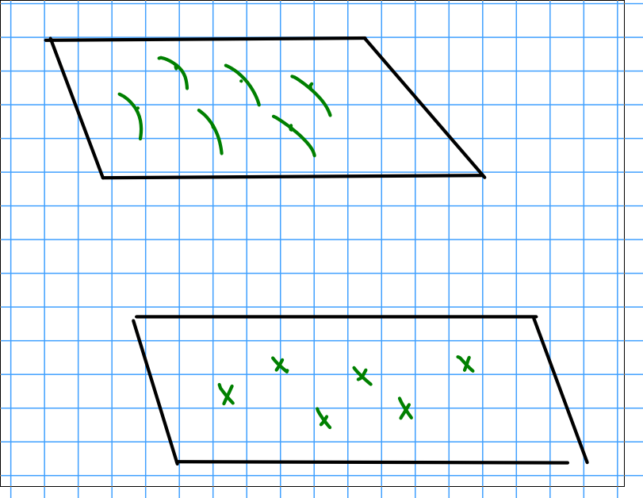

Image

Let $\ell = \pi^*(\text{line})$, then a fact is that $3\ell - E_1 -\cdots - E_6$ (where $E_i$ are the curves about the $p_i$) is very ample and embeds $X$ into ${\mathbb{P}}^3$ as a cubic.

Every smooth cubic surface $X$ has *precisely* 27 lines. Any 6 pairwise skew lines arise as $E_1, \cdots, E_6$ as in the previous construction.

Take an $X$ and a line $L\subset X$. Consider any $C$ in the linear system ${\left\lvert {4H + 2L} \right\rvert}$. Fact: ${\mathcal{O}}(4H + 2L)$ is very ample, so embeds into a big projective space, and thus $C$ is smooth and irreducible by Bertini. Then the Hilbert polynomial of $C$ is of the form $at + b$ where $b = \chi({\mathcal{O}}_c)$, the Euler characteristic of the structure sheaf of $C$, and $a = \deg C$. So we’ll compute these. We have $\deg C = H \cdot C$ (intersection) $= H \cdot(4H + 2L) = 4H^2 + 2H\cdot L = 4\cdot 3 + 2 = 14$. The intersections here correspond to taking hyperplane sections, intersecting with $X$ to get a curve, and counting intersection points:

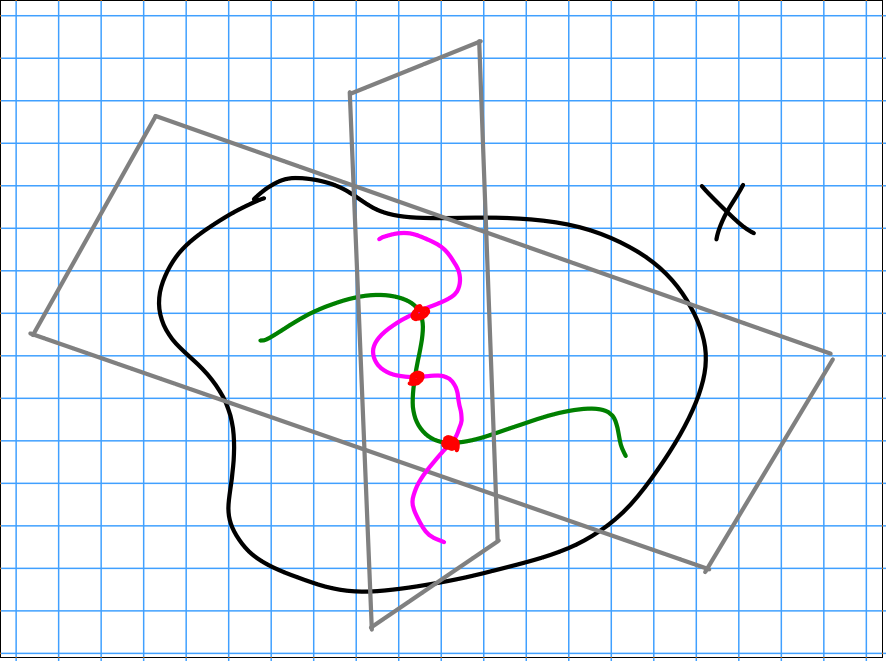

In general, for $X$ a surface and $C\subset X$ a smooth curve, then $\omega_C = \omega_X(C)\mathrel{\Big|}_C$. Since $X\subset {\mathbb{P}}^3$, we have
$$\begin{align*}
\omega_X
&= \omega_{{\mathbb{P}}^3}(X) \mathrel{\Big|}_X \\
&= {\mathcal{O}}(-4) \oplus {\mathcal{O}}(3)\mathrel{\Big|}_X \\
&= {\mathcal{O}}_X(-1) \\
&= {\mathcal{O}}_X(-H)
.\end{align*}
We also have
\begin{align*}
\omega_C
&= \omega_X(C)\mathrel{\Big|}_X \\
&= { \left.{{ \qty{ {\mathcal{O}}_X(-H) \oplus {\mathcal{O}}_X(4H + 2L)}}} \right|_{{C}} } \\ \\
&\Downarrow \qquad \text{taking degrees} \\ \\
\deg \omega_C
&= C\cdot(3H + 2L) \\
&= (4H+2L)(3H+2L) \\
&= 12H^2 + 14HL + 4L^2 \\
&= 36 + 14 + (-4) \\
&= 46
.\end{align*}
Since this equals \(2g(C) - 2\), we can conclude that the genus is given by \(g(C) = 24\). Thus \(P\) is given by \(14t + (1-g) = 14t - 23\).$$

Good to know: moving a cubic surface moves the lines, you get a monodromy action, and the Weyl group of $E_6$ acts transitively so lines look the same.

There is a flat family $Z\subset {\mathbb{P}}^3_S$ with fiberwise Hilbert polynomial $P$ of cures of this form such that the image of the map $S \to \operatorname{Hilb}_{{\mathbb{P}}^3}^P$ has dimension 56.

We can compute the dimension of the space of smooth cubic surfaces, since these live in ${\mathbb{P}}H^0({\mathbb{P}}^3, {\mathcal{O}}(3))$, which has dimension ${3+3\choose 3} -1 = 19$. Since there are 27 lines, the dimension of the space of such cubics with a choices of a line is also 19. Choose a general $C$ in the linear system ${\left\lvert {4H + 2L} \right\rvert}$ will add $\dim {\left\lvert {4H + 2L} \right\rvert} = \dim {\mathbb{P}}H^0(x, {\mathcal{O}}_x(C))$. We have an exact sequence
$$\begin{align*}
0 \to {\mathcal{O}}_X \to {\mathcal{O}}_X(C) \to {\mathcal{O}}_C(C) \to 0 \\
H^0\qty{ 0 \to {\mathcal{O}}_X \to {\mathcal{O}}_X(C) \to {\mathcal{O}}_C(C) \to 0 } \\
.\end{align*}$$

Since the first $H^0$ vanishes (?) we get an isomorphism. By Riemann-Roch, we have
$$\begin{align*}
\deg {\mathcal{O}}_C(C) = C^2 = (4H+2L)^2 = 16H^2 + 16 HL + 4L^2 = 64 - 4 = 60
.\end{align*}$$

We can also compute $\chi({\mathcal{O}}_C(C)) = 60 - 23 = 37$. We have
$$\begin{align*}
h^0({\mathcal{O}}_C(C)) - h^1({\mathcal{O}}_C(C)) = h^0({\mathcal{O}}_C(C)) - h^0(\omega_C(-C))) = 2(23) - 60 < 0
,\end{align*}
so there are no sections.$$

For any $C$ above, we have $\dim T_C H = 57$.

When the subscheme is smooth, we have an identification with sections of the normal bundle $T_C H = H^0(C, N_{C/{\mathbb{P}}^3})$. There’s an exact sequence

$$\begin{align*}
0 \to N_{C/X} = {\mathcal{O}}_C(C) \to N_{C/{\mathbb{P}}^3} \to N_{X/{\mathbb{P}}^3}\mathrel{\Big|}_C = {\mathcal{O}}_C(x)\mathrel{\Big|}_C = {\mathcal{O}}_C(3H)\mathrel{\Big|}_C \to 0
.\end{align*}$$

> Note $\omega_C = {\mathcal{O}}_C(3H + 2L)$.

As we computed,
$$\begin{align*}
H^0({\mathcal{O}}_C(C)) &= 37 \\
H^1({\mathcal{O}}_C(C)) &= 0
.\end{align*}$$

$$\begin{align*}
0 \to {\mathcal{O}}_X(2L-C) \to {\mathcal{O}}_X(2L) \to {\mathcal{O}}_C(2L) \to 0
.\end{align*}$$

Taking homology, we have $0\to 0 \to 1 \to 1 \to 0$ since $2L-C = -4H$. Computing degrees yields $h^0 ({\mathcal{O}}_C(3H)) = 20$. Thus the original exact sequence yields
$$\begin{align*}
0 \to 37 \to ? \to 20 \to 0
,\end{align*}
so \(? = 57\) and thus \(\dim N_{C/{\mathbb{P}}^3} = 57\).$$

$$\begin{align*}
\dim H = 56
.\end{align*}$$

### 9.1.1 Proof That the Dimension is 56

Suppose otherwise. Then we have a family over $H^\mathrm{red}$ of *smooth* curves, where $f(S) \subset H^\mathrm{red}$, where the generic element is not on a cubic or any lower degree surface. Let $C'$ be a generic fiber. Then $C'$ lies on a pencil of quartics, i.e. 2 linearly independent quartics. Let $I = I_{C'}$ be the ideal of this curve in ${\mathbb{P}}^3$, there is a SES
$$\begin{align*}
0\to I(4) \to {\mathcal{O}}(4) \to {\mathcal{O}}_C(4) \to 0
.\end{align*}
It can be shown that \(\dim H^0(I(4)) \geq 2\).$$

A generic quartic in this pencil is *smooth* (can be argued because of low degree and smoothness).

We can compute the dimension of quartics, which is ${4+3 \choose 3} - 1 = 35 - 1 = 34$. The dimension of $C'$s lying on a fixed quartic is $24$. But then the dimension of the image in the Hilbert scheme is at most $24 + 34 - 1 = 57$. It can be shown that the picard rank of such a quartic is 1, generated by ${\mathcal{O}}(1)$, so this is a *strict* inequality, which is a contradiction since $\dim \operatorname{Hilb}= 56$. This proves the theorem.

Use the fact that these curves are $K3$ surfaces? Get the fact about the generator of the Picard group from Hodge theory. So we can deform curves a bit, but not construct an algebraic family that escapes a particular cubic.

# 10 Obstruction and Deformation (Tuesday February 25th)

Let $k$ be a field, $X_{_{/k}}$ projective, then the $k{\hbox{-}}$points $\operatorname{Hilb}_{X_{_{/k}}}^P(k)$ corresponds to closed subschemes $Z\subset X$ with hilbert polynomial $P_z = P$. Given a $P$, we want to understand the local structure of $\operatorname{Hilb}_{X_{_{/k}}}^p$, i.e. diagrams of the form

[figure not shown]

For $A = k[\varepsilon]$, the set of extensions is the Zariski tangent space.

Let $(\operatorname{Art}_{/k})$ be the category of local Artinian $k{\hbox{-}}$algebras with local residue field $k$.

Note that these will be the types of algebras appearing in the above diagrams.

This category has fiber coproducts, i.e. there are pushouts:

[figure not shown]

There are also fibered products,

[figure not shown]

Here, $A \times_C B \mathrel{\vcenter{:}}=\left\{{(a, b) {~\mathrel{\Big|}~}f(a) = g(b)}\right\} \subset A\times B$.

If $A = B = k[\varepsilon]/(\varepsilon^2)$ and $C = k$, then $A\times_C B = k[\varepsilon_1, \varepsilon_2]/(\varepsilon_1, \varepsilon_2)^2$

Note that on the $\operatorname{Spec}$ side, these should be viewed as
$$\begin{align*}
\operatorname{Spec}(A) {\coprod}_{\operatorname{Spec}(C)} \operatorname{Spec}(B) = \operatorname{Spec}(A\times_C B)
.\end{align*}$$

A *deformation functor* is a functor $F: (\operatorname{Art}_{/k}) \to {\operatorname{Set}}$ such that $F(k) = {\{\operatorname{pt}\}}$ is a singleton.

Let $X_{_{/k}}$ be any scheme and let $x\in X(k)$ be a $k{\hbox{-}}$point. We can consider the deformation functor $F$ such that $F(A)$ is the set of extensions $f$ of the following form:

[figure not shown]

If $A' \to A$ is a morphism, then we define $F(A') \to F(A)$ is defined because we can precompose to fill in the following diagram

[figure not shown]

So this is indeed a deformation functor.

The Zariski tangent space on the nodal cubic doesn’t “see” the two branches, so we allow “second order” tangent vectors.

We can consider parametrizing the functors above as $F_{X, x}(A)$, which is isomorphic to $F_{\operatorname{Spec}({\mathcal{O}}_x)_{X, x}}$ and further isomorphic to $F_{\operatorname{Spec}\widehat{{\mathcal{O}}_x}_{x, X} }$. This is because for Artinian algebras, we have maps
$$\begin{align*}
\operatorname{Spec}({\mathcal{O}}_{x, X})/{\mathfrak{m}}^N \to \operatorname{Spec}{\mathcal{O}}_{X, x} \to X
.\end{align*}$$

$\widehat{ {\mathcal{O}}}_{X, x}$ will be determined by $F_{X, x}$.

Consider $y^2 = x^2(x+1)$, and think about solving this over $k[t]/t^n$ with solutions equivalent to $(0, 0) \pmod t$.

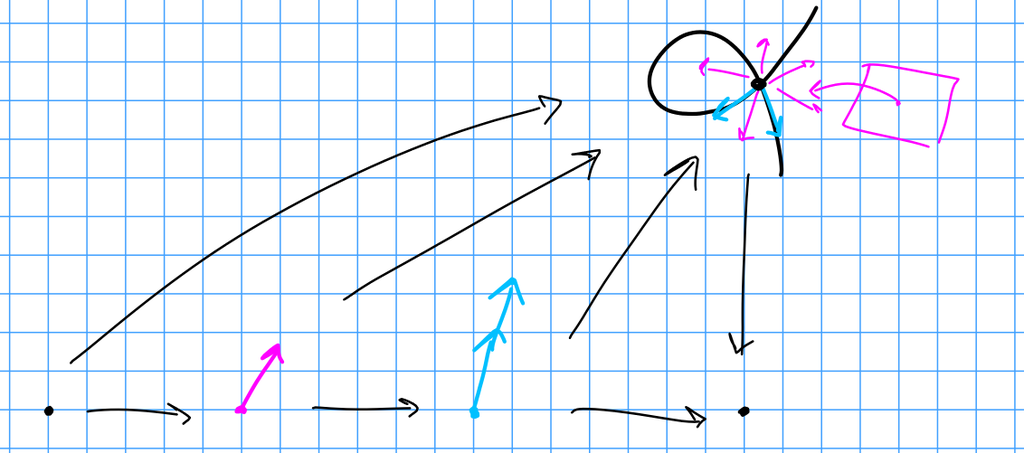

Note that the ‘second order’ tangent vector comes from $\operatorname{Spec}k[t]/t^3$.

We can write $F_{X, x}(A) = \pi^{-1}(x)$ where
$$\begin{align*}
\hom_{{\operatorname{Sch}}_{/k}}(\operatorname{Spec}k, X) \xrightarrow{\pi} \hom_{{\operatorname{Sch}}_{/k}}(\operatorname{Spec}k, x) \ni x
.\end{align*}
Thus
\begin{align*}
F_{X, x}(A) = \hom_{{\operatorname{Sch}}_{/k}}(\operatorname{Spec}A, \operatorname{Spec}{\mathcal{O}}_{x, X}) = \hom_{k{\hbox{-}}\mathrm{Alg}}(\widehat{{\mathcal{O}}}_{X, x}, A)
.\end{align*}$$

Given any local $k{\hbox{-}}$algebra $R$, we can consider

$$\begin{align*}
h_R: (\operatorname{Art}_{/k}) &\to {\operatorname{Set}}\\
A &\mapsto \hom(R, A)
.\end{align*}$$

and

$$\begin{align*}
h_{\operatorname{Spec}R}: (\operatorname{Art}{\operatorname{Sch}}_{/k})^{\operatorname{op}}\to {\operatorname{Set}}\\
\operatorname{Spec}(A) &\mapsto \hom(\operatorname{Spec}A, \operatorname{Spec}R)
.\end{align*}$$

A deformation $F$ is **representable** if it is of the form $h_R$ as above for some $R \in \operatorname{Art}_{/k}$.

There is a Yoneda Lemma for $A\in \operatorname{Art}_{/k}$,
$$\begin{align*}
\hom_{\mathrm{Fun}}(h_A, F) = F(A)
.\end{align*}$$

We are thus looking for things that are representable in a larger category, which restrict.

A deformation functor is *pro-representable* if it is of the form $h_R$ for $R$ a complete local $k{\hbox{-}}$algebra (i.e. a limit of Artinian local $k{\hbox{-}}$algebras).

We will see that there are simple criteria for a deformation functor to be pro-representable. This will eventually give us the complete local ring, which will give us the scheme representing the functor we want.

It is difficult to understand even $F_{X, x}(A)$ directly, but it’s easier to understand small extensions.

A *small extension* is a SES of Artinian $k{\hbox{-}}$algebras of the form
$$\begin{align*}
0 \to J \to A' \to A \to 0
.\end{align*}
such that \(J\) is annihilated by the maximal ideal fo \(A'\).$$

Given any quotient $B\to A \to 0$ of Artinian $k{\hbox{-}}$algebras, there is a sequence of small extensions (quotients):

[figure not shown]

This yields

[figure not shown]

where the $\operatorname{Spec}B_i$ are all small.

In most cases, extending deformations over small extensions is easy.

## 10.1 First Example of Deformation and Obstruction Spaces

Suppose $k=\mkern 1.5mu\overline{\mkern-1.5muk\mkern-1.5mu}\mkern 1.5mu$ and let $X_{_{/k}}$ be connected. We have a picard functor
$$\begin{align*}
{\operatorname{Pic}}_{X_{_{/k}}}: ({\operatorname{Sch}}_{/k})^{\operatorname{op}}&\to {\operatorname{Set}}\\
S &\mapsto {\operatorname{Pic}}(X_S) / {\operatorname{Pic}}(S)
.\end{align*}
If we take a point \(x\in {\operatorname{Pic}}_{X_{_{/k}}}(k)\), which is equivalent to line bundles on \(X\) up to equivalence, we obtain a deformation functor
\begin{align*}
F \mathrel{\vcenter{:}}= F_{{\operatorname{Pic}}_{ X_{_{/k}}, x }} &\to {\operatorname{Set}}\\
A \mapsto \pi^{-1}(x)
\end{align*}
where
\begin{align*}
\pi: {\operatorname{Pic}}_{X_{_{/k}}}(\operatorname{Spec}A) &\to {\operatorname{Pic}}_{X_{_{/k}}} (\operatorname{Spec}k) \\
\pi^{-1}(x) &\mapsto x
.\end{align*}$$

# 11 Deformation Theory (Thursday February 27th)

Big picture idea: We have moduli functors, such as

$$\begin{align*}
F_{S'}: ({\operatorname{Sch}}_{/k})^{\operatorname{op}}&\to {\operatorname{Set}}\\
\operatorname{Hilb}: S &\to \text{flat subschemes of } X_S \\
{\operatorname{Pic}}: S &\to {\operatorname{Pic}}(X_S)/{\operatorname{Pic}}(S) \\
\mathrm{Def}: S &\to \text{flat families } / S,~ \text{smooth, finite, of genus } g
.\end{align*}$$

Choose a point $f$ the scheme representing $F_{S'}$ with $\xi_0 \in F_{gl}(\operatorname{Spec}K)$. Define

$$\begin{align*}
F_{\text{loc}}: (\text{Artinian local schemes} / K)^{\operatorname{op}}\to {\operatorname{Set}}
.\end{align*}$$

[figure not shown]

Let $F: (\operatorname{Art}_{/k}) \to {\operatorname{Set}}$ where $F(k)$ is a point. Denote $\widehat{\operatorname{Art}}_{/k}$ the set of complete local $k{\hbox{-}}$algebras. Since $\operatorname{Art}_{/k} \subset \widehat{\operatorname{Art}} / k$, we can make extensions $\widehat{F}$ by just taking limits:

[figure not shown]

where we define
$$\begin{align*}
\widehat{F}(R) \mathrel{\vcenter{:}}=\varprojlim F(R/{\mathfrak{m}}_R^n)
.\end{align*}$$

When is $F$ pro-representable, which happens iff $\widehat{F}$ is representable? In particular, we want $h_R \xrightarrow{\cong} \widehat{F}$ for $R\in \widehat{\operatorname{Art}}_{/k}$, so
$$\begin{align*}
h_R = \hom_{\widehat{\operatorname{Art}}_{/k}}(R, {\,\cdot\,}) = \hom_{?}({\,\cdot\,}, \operatorname{Spec}k)
.\end{align*}$$

Let $F_{\text{gl}} = \operatorname{Hilb}_{X_{_{/k}}}^p$, which is represented by $H_{/k}$. Then .
$$\begin{align*}
\xi_0 = F_{\text{gl}}(k) = H(k) = \left\{{Z\subset X {~\mathrel{\Big|}~}P_z = f}\right\}
.\end{align*}
Then \(F_{\text{loc} }\) is representable by \(\widehat{{\mathcal{O}}}_{H/\xi_0}\).$$

Given an Artinian $k{\hbox{-}}$algebra $A \in \operatorname{Art}_{/k}$, a *thickening* is an $A' \in \operatorname{Art}_{/k}$ such that $0 \to J \to A' \to A \to 0$, so $\operatorname{Spec}A \hookrightarrow\operatorname{Spec}A'$.

A **small thickening** is a thickening such that $0 = {\mathfrak{m}}_{A'} J$, so $J$ becomes a module for the residue field, and $\dim_k J = 1$.

Any thickening of $A$, say $B\to A$, fits into a diagram:

[figure not shown]

We just need $I' \subset I$ with ${\mathfrak{m}}_S I \subset J' \subset I \iff J {\mathfrak{m}}_B = 0$. Choose $J'$ to be a preimage of a codimension 1 vector space in $I/{\mathfrak{m}}_B I$. Thus $J = I/I'$ is 1-dimensional.

Thus any thickening $A$ can be obtained by a sequence of small thickenings. By the lemma, in principle $F$ and thus $\widehat{F}$ are determined by their behavior under small extensions.

### 11.0.1 Example

Consider ${\operatorname{Pic}}$, fix $X_{_{/k}}$, start with a line bundle $L_0 \in {\operatorname{Pic}}(x) /{\operatorname{Pic}}(k) = {\operatorname{Pic}}(x)$ and the deformation functor $F(A)$ being the set of line bundles $L$ on $X_A$with ${\left.{{L}} \right|_{{x}} } \cong L_0$, modulo isomorphism. Note that this yields a diagram

[figure not shown]

This is equal to $(I_x)^{-1}(L_0)$, where ${\operatorname{Pic}}(X_a) \xrightarrow{I_x} {\operatorname{Pic}}(x)$. If
$$\begin{align*}
0 \to J \to A' \to A \to 0
.\end{align*}
is a small thickening, we can identify$$

[figure not shown]

This yields a LES

[figure not shown]

To understand $F$ on small extensions, we’re interested in

1. Given $L \in F_{\text{loc}}(A)$, i.e. $L$ on $X_A$ restricting to $L_0$, when does it extend to $L' \in F_{\text{loc}}(A')$? I.e., does there exist an $L'$ on $X_{A'}$ restricting to $L$?
2. Provided such an extension $L'$ exists, how many are there, and what is the structure of the space of extensions?

We have an $L\in {\operatorname{Pic}}(X_A)$, when does it extend?

By exactness, $L'$ exists iff $\text{obs}(L) = 0\in H^2(X, {\mathcal{O}}_x)$, which answers 1. To answer 2, $(I_x)^{-1}(L)$ is the set of extensions of $L$, which is a torsor under $H^1(x, {\mathcal{O}}_x)$. Note that these are fixed $k{\hbox{-}}$vector spaces.

$H^1(X, {\mathcal{O}}_x)$ is interpreted as the **tangent space** of the functor $F$, i.e. $F_{\text{loc}}(K[\varepsilon])$. Note that if $X$ is projective, line bundles can be unobstructed without the group itself being zero.

For (3), just play with $A = k[\varepsilon]$, which yields $0 \to k \xrightarrow{\varepsilon} k[\varepsilon] \to k \to 0$, then

[figure not shown]

i.e., there is a canonical trivial extension $L_0[\varepsilon]$.

Let $X \supset Z_0 \in \operatorname{Hilb}_{X_{_{/k}}}(k)$, we computed
$$\begin{align*}
T_{Z_0} \operatorname{Hilb}_{X_{_{/k}}} = \hom_{{\mathcal{O}}_x}(I_{Z_0}, {\mathcal{O}}_z)
.\end{align*}
We took \(Z_0 \subset X\) and extended to \(Z' \subset X_{k[\varepsilon]}\) by base change. In this case, \(F_{\text{loc}}(A)\) was the set of \(Z'\subset X_A\) which are flat over \(A\), such that base-changing \(Z' \times_{\operatorname{Spec}A} \operatorname{Spec}k \cong Z\). This was the same as looking at the preimage restricted to the closed point,
\begin{align*}
\operatorname{Hilb}_{X_{_{/k}}}(A) \xrightarrow{i^*} \operatorname{Hilb}_{X_{_{/k}}}(k) \\
(i^*)^{-1}(z_0) \mapsfrom z_0
.\end{align*}
Recall how we did the thickening: we had \(0 \to J \to A' \to A \to 0\) with \(J^2 = 0\), along with \(F\) on \(X_A\) which is flat over \(A\) with \(X_{_{/k}}\) projective, and finally an \(F'\) on \(X_{A'}\) restricting to \(F\). The criterion we had was \(F'\) was flat over \(A'\) iff \(0 \to J\otimes_{A'} F' \to F'\), i.e. this is injective. Suppose \(z\in F_{\text{loc}}(A)\) and an extension \(z' \in F_{\text{loc}}(A')\). By tensoring the two exact sequences here, we get an exact grid:$$

[figure not shown]

The space of extension should be a torsor under $\hom_{{\mathcal{O}}_X}(I_{Z_0}, {\mathcal{O}}_{Z_0})$, which we want to think of as $\hom_{{\mathcal{O}}_X}(I_{Z_0}, {\mathcal{O}}_{Z_0})$. Picking a $\phi$ in this hom space, we want to take an extension $I_{Z'} \xrightarrow{\phi} I_{Z''}$.

> We’ll cover how to make this extension next time.

# 12 Tuesday March 31st

See notes on Ben’s website. We’ll review where we were.

## 12.1 Deformation Theory

We want to represent certain moduli functors by schemes. If we know a functor is representable, it’s easier to understand the deformation theory of it and still retain a lot of geometric information. The representability of deformation is much easier to show. We’re considering functors $F: \operatorname{Art}_{/k} \to {\operatorname{Set}}$.

The Hilbert functor
$$\begin{align*}
\operatorname{Hilb}_{X_{_{/k}}} ({\operatorname{Sch}}_{/k})^{\operatorname{op}}\to {\operatorname{Set}}\\
S \mapsto \left\{{ Z \subset X \times S \text{ flat over } S}\right\}
.\end{align*}$$

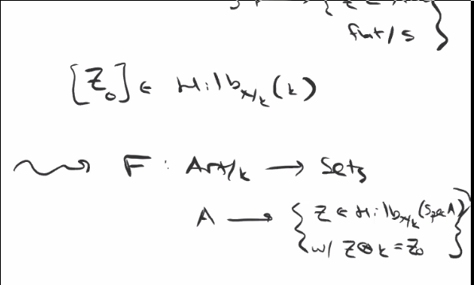

Image

Recall that we’re interested in pro-representability, where $\widehat{F}(R) = \varprojlim F(R\mu_R^n)$ is given by a lift of the form

[figure not shown]

Is $\widehat{F}$ representable, i.e. is $F$ pro-representable?

The $F$ in the previous example is pro-representable by $\widehat{F} = \hom({\mathcal{O}}_{\operatorname{Hilb}, z_0}, {\,\cdot\,})$.

$F$ has a *pro-representable hull* iff there is a formally smooth map $h_R \to F$.

Does $F$ have a pro-representable hull?

Recall that a map of functors on artinian $k{\hbox{-}}$algebras is **formally smooth** if it can be lifted through nilpotent thickenings. That is, for $F, G: \operatorname{Art}_{/k} \to {\operatorname{Set}}$, $F \to G$ is *formally smooth* if for any thickening $A' \twoheadrightarrow A$, we have

[figure not shown]

We proved for $R, A$ finite type over $k$, $\operatorname{Spec}R \to \operatorname{Spec}A$ smooth is formally smooth. Given a complete local $k{\hbox{-}}$algebra $R$ and a section $\xi \in \widehat{F}(R)$, we make the following definitions:

The pair $(R, \xi)$ is

- *Versal* for $F$ iff $h_R \xrightarrow{\xi} F$ is formally smooth.[^5]
- *Miniversal* for $F$ iff versal and an isomorphism on Zariski tangent spaces.
- *Universal* for $F$ if $h_R \xrightarrow{\cong} F$ is an isomorphism, i.e. $h_R$ pro-represents $F$.
  - Pullback by a unique map

Note that **versal** means that any formal section $(s, \eta)$ where $\eta \in \widehat{F}(s)$ comes from pullback, i.e there exists a map
$$\begin{align*}
R &\to S \\
\widehat{F}(R) &\to \widehat{F}(s) \\
\xi &\mapsto \eta
.\end{align*}$$

**Miniversal** means adds that the derivative is uniquely determined, and universal means that $R\to S$ is unique.

An **obstruction theory** for $F$ is the data of $\mathrm{def}(F), \mathrm{obs}(F)$ which are finite-dimensional $k{\hbox{-}}$vector spaces, along with a functorial assignment of the following form: \begin{align*} (A' \twoheadrightarrow A) \quad \text{a small thickening } \mapsto \\ \mathrm{def}(F) {\circlearrowleft}F(A') \to F(A) \xrightarrow{\mathrm{obs}} \mathrm{obs}(F) \end{align*} that is exact[^6] and if $A=k$, it is exact on the left (so the action was faithful on nonempty fibers).

We have
$$\begin{align*}
{\operatorname{Pic}}_{X_{/k}} : ({\operatorname{Sch}}_{/k})^{\operatorname{op}}&\to {\operatorname{Set}}\\
S &\mapsto {\operatorname{Pic}}(X\times X) / {\operatorname{Pic}}(S)
.\end{align*}$$

This yields
$$\begin{align*}
F: \operatorname{Art}_{/k} \to {\operatorname{Set}}\\
A \mapsto L\in {\operatorname{Pic}}(X_A),~ L\otimes k \cong L_0
\end{align*}
where \(X_{_{/k}}\) is proper and irreducible. Then \(F\) has an obstruction theory with \(\mathrm{def}(F) = H^1({\mathcal{O}}_x)\) and \(\mathrm{obs}(F) = H^2({\mathcal{O}}_x)\). The key was to look at the LES of
\begin{align*}
0 \to {\mathcal{O}}_x \to {\mathcal{O}}_{X_{A'}}^* \to {\mathcal{O}}_{X_A}^* \to 0
.\end{align*}$$

for $0 \to k \to A' \to A \to 0$ small.

In both cases, the obstruction theory is exact on the left for any small thickening. We will prove the following:

- $F$ has an obstruction $\iff$ it has a pro-representable hull, i.e. a versal family
- $F$ has an obstruction theory which is always exact at the left $\iff$ it has a universal family.

## 12.2 Schlessinger’s Criterion

Let $F: \operatorname{Art}_{/k} \to {\operatorname{Set}}$ be a deformation functor (and it only makes sense to talk about deformation functors when $F(k) = {\{\operatorname{pt}\}}$). This theorem will tell us when a miniversal and a universal family exists.

$F$ has a miniversal family iff

1. Gluing along common subspaces: ror any small $A' \to A$ and $A'' \to A$ any other thickening, the map
   $$\begin{align*}
   F(A' \times_A A'') \to F(A') \times_{F(A)} F(A'')
   \end{align*}
   is surjective.$$
2. Unique gluing: if $(A' \to A) = (k[\varepsilon] \to k)$, then the above map is bijective.
3. $t_F = F(k[\varepsilon])$ is a finite dimensional $k{\hbox{-}}$vector space, i.e.
   $$\begin{align*}
   F(k[\varepsilon] \times_k k[\varepsilon]) \xrightarrow{\cong} F(k[\varepsilon]) \times F(k[\varepsilon])
   .\end{align*}$$
4. For $A' \to A$ small,

[figure not shown]

where the action is simply transitive.

$F$ has a miniversal family iff (1)-(3) hold, and universal iff all 4 hold.

Show that the existence of an obstruction theory which is exact on the left implies (1)-(4).

The following diagram commutes:

[figure not shown]

So we have a map $F(A' \times_A A'') \to F(A') \times_{F(A)} F(A'') \ni (\xi',\xi'')$. Using transitivity of the $\mathrm{def}$ action, we can get $\xi' = \eta' + \theta$ and thus $\eta + \theta$ is the lift.

## 12.3 Abstract Deformation Theory

We start with $\qty{X_0}_{/k}$ and define the functor $F$ sending $A$ to $X/A$ flat families over $A$ with $X_0 \hookrightarrow^i X$ such that $i \otimes k$ is an isomorphism. The punchline is that $F$ has an obstruction theory if $X_0$ is smooth with

- $\mathrm{def}(F) = H^1(T_{X_0})$
- $\mathrm{obs}(F) = H^2(T_{X_0})$
1. If $X$ is a deformation of $X_0$ over $A$ and we have a small extension $k \to A'\to A$ with $X'$ over $A'$ a lift of $X$. Then there is an exact sequence
   $$\begin{align*}
   0 \to \text{Der}_R({\mathcal{O}}_{X_0}) \to\operatorname{Aut}_{A'}(X') \to \operatorname{Aut}_A(X)
   .\end{align*}$$
2. If $\qty{X_0}_{/k}$ is smooth and *affine*, then any deformation $X$ over $A$ (a flat family restricting to $X_0$) is trivial, i.e. $X \cong X_0 \times_k \operatorname{Spec}(A)$.

[figure not shown]

Thus $X_0 \hookrightarrow X$ has a section $X\to X_0$, and the claim is that this forces $X$ to be trivial.

We have

[figure not shown]

yielding
$$\begin{align*}
0 \to K \to {\mathcal{O}}_{X_0} \otimes A \to {\mathcal{O}}_X \to 0 \\
({\,\cdot\,}\otimes k) \\
1 \to k\otimes k = 0 \to {\mathcal{O}}_{X_0} \xrightarrow{\cong} {\mathcal{O}}_{X_0} \to 0
.\end{align*}$$

Why does this involve cohomology of the tangent bundle? For $X_0$ smooth, $\operatorname{Der}_k({\mathcal{O}}_{X_0}) = \mathcal{H}(T_{X_0})$, but the LHS is equal to $\hom( \Omega_{ \qty{X_0}_{/k}}, {\mathcal{O}}_{X_0}) = H^0 (T_{X_0})$.

> Upcoming: proof of Schlessinger so we can use it!

# 13 Thursday April 2nd

## 13.1 Abstract Deformations

Let $X_0$ be smooth and consider the deformation functor
$$\begin{align*}
F : \operatorname{Art}_{_{/k}} &\to {\operatorname{Set}}\\
A &\mapsto (X_{/A} , \iota)
\end{align*}
where \(X\) is flat (and thus smooth) and \(i\) is a closed embedding \(i: X_0 \hookrightarrow X\) with \(i\otimes k\) an isomorphism.$$

Then $F$ has an obstruction theory with

- $\mathrm{def}(F) = H^1(X_0, T_0)$ of the tangent bundle
- $\mathrm{obs}(F) = H^2(X_0, T_0)$.

Additionally assume $X_0$ is smooth and projective, which will force the above cohomology groups to be finite-dimensional over $k$.

- All deformations of smooth affine schemes are trivial
- Automorphisms of a deformation $X/A$ which are the identity on $X_0$ are $\operatorname{id}+ \delta$ for $\delta$ a derivation in $\operatorname{Der}_k({\mathcal{O}}_{X_0}) = \hom_{{\mathcal{O}}_{X_0}}(\Omega_{\qty{X_0}_{_{/k}}}, {\mathcal{O}}_{X_0})$.

Suppose we have a small thickening $k \to {\mathbb{A}}^1 \to {\mathbb{A}}$ and $X/{\mathbb{A}}$ with an affine cover $X_\alpha$ of $X$. This comes with gluing information $\phi_{\alpha\beta}: X_{\alpha\beta} \to X_{\beta\alpha} = X_\alpha \cap X_\beta$. These maps satisfy a cocycle condition:

[figure not shown]

Can we extend this to $X'/{\mathbb{A}}$?

We have $X_\alpha \cong X_\alpha^\mathrm{red} \times{\mathbb{A}}$? Choose $\phi'_{\alpha\beta}$ such that

[figure not shown]

We need $\phi'_{\alpha\beta}$ to satisfy the cocycle condition in order to glue. We want the following map to be the identity: $(\phi'_{\alpha\gamma})^{-1}\phi'_{\beta\gamma} \phi'_{\alpha\beta}$. This is an automorphism of $X'_{\alpha\beta} \cap X'_{\alpha\beta}$ and is thus the identity in $\operatorname{Aut}(X_{\alpha\beta} \cap X_{\alpha\gamma})$. So it makes sense to talk about
$$\begin{align*}
\delta_{\alpha\beta\gamma}
\mathrel{\vcenter{:}}=
(\phi'_{\alpha\gamma})^{-1}
\phi'_{\beta\gamma}
\phi'_{\alpha\beta} -
\operatorname{id}\in
M^0(T_{X^\mathrm{red}_{\alpha\beta\gamma}})
.\end{align*}$$

In parts,

1. $\delta_{\alpha\beta\gamma}$ is a $2{\hbox{-}}$cocycle for $T_{X_0}$, so it has trivial boundary in terms of Cech cocycles. Thus $[\delta_{\alpha\beta\gamma}] \in H^2(T_{X_0})$.
2. The class $[\delta_{\alpha\beta\gamma}]$ is independent of choice of $\phi'_{\alpha\beta}$, i.e. $\phi'_{\alpha\beta} - \phi_{\alpha\beta}'' \in H^0((T_X)_{\alpha\beta})$ gives a coboundary $\eta$ and thus $\delta = \delta' + \eta$. This yields $\mathrm{obs}(X) \in H^2(T_{X_0})$.
3. $\mathrm{obs}(X) = 0 \iff X$ lifts to some $X'$ (i.e. a lift exists)

For the sufficiency, we have $\delta_{\alpha\beta\gamma} = {{\partial}}\eta_{\alpha\beta} \in H^0(T_{X_{\alpha\beta}})$. Let $\phi_{\alpha\beta}'' = \phi_{\alpha\beta}' - \eta_{\alpha\beta}$, the claim is that $\phi_{\alpha\beta}''$ satisfies the gluing condition. This covers the obstruction, so now we need to show that the set of lifts is a torsor for the action of the deformation space $\mathrm{def}(F) = H^1(T_{X_0})$. From an $X'$, we obtain $X_{\alpha\beta}' \xrightarrow{\phi_{\alpha\beta}'} X_{\beta\alpha}'$ where the LHS is isomorphic to $(X_{\alpha\beta}')^\mathrm{red} \times{\mathbb{A}}^r$? Given $\eta_{\alpha\beta} \in H^0(T_{X_{\alpha\beta}})$, then $\phi'_{\alpha\beta} + \eta_{\alpha\beta} = \phi_{\alpha\beta}''$ is another such identification.

In parts

1. ${{\partial}}\eta_{\alpha\beta} = 0$.
2. Given an $X'$ and 1-coboundary $\eta$, we get a new lift $X'' = X' + \eta$. If $[\eta] = [\eta'] \in H^1(T_{X_0})$, then $X' + \eta \cong X' + \eta'$.

By construction, $(X' + \eta)_\alpha \cong (X' + \eta')_\alpha$, but these may not patch together. However, if $[\eta] = [\eta']$ then this isomorphism can be modified by by $\varepsilon$ defined by $\eta-\eta' = {{\partial}}\varepsilon$, and it patches.

This kind of patching is ubiquitous – essentially patching together local obstructions to get a global one. In general, there is a local-to-global spectral sequence that computes the obstruction space

## 13.2 Proving Schlessinger

### 13.2.1 The Schlessinger Axioms

#### 13.2.1.1 H1

For any two small thickenings
$$\begin{align*}
A' &\to A \\
A'' &\to A
\end{align*}$$

we have a natural map
$$\begin{align*}
F(A' \times_A A'') \to F(A') \times_{F(A)} F(A'')
\end{align*}
and we require that this map is surjective. So deformations agreeing on the sub glue together.$$

#### 13.2.1.2 H2

When $(A' \to A) = (k[\varepsilon] \to k)$ is the trivial extension, the map in H1 is an isomorphism.

> Doing things to first order is especially simple.

#### 13.2.1.3 H3

The tangent space of $F$ is given by $t_F = F(k[\varepsilon])$, and we require that $\dim_k t_F < \infty$, which makes sense due to H2.

#### 13.2.1.4 H4

If we have two equal small thickenings $(A' \to A) = (A'' \to A)$, then the map in H1 is an isomorphism.

#### 13.2.1.5 H4’

For $A' \to A$ small,
$$\begin{align*}
t_F {\circlearrowleft}F(A') \to F(A)
\end{align*}
is exact in the middle and left.$$

Note that the existence of this action uses H2.

For $(R, \xi)$ a complete local ring and $\xi \in \widehat{F}(R)$ a formal family, this is a hull $\iff$ miniversal, i.e. for $h_R \xrightarrow{\xi} F$, this is smooth an isomorphism on tangent spaces.

1. $F$ has a miniversal family $(R, \xi)$ with $\dim t_R < \infty$, noting that $t_R = {\mathfrak{m}}_R / {\mathfrak{m}}_R^2$, iff H1-H3 hold.
2. $F$ has a universal family $(R, \xi)$ with $\dim t_R < \infty$ iff h1-H4 hold.
1. $F$ having an obstruction theory implies H1-H3.
2. $F$ having a strong obstruction theory (exact on the left) is equivalent to H1-H4.

Some preliminary observations:

If $F$ has an obstruction theory, then H1-H3 hold.

An obstruction theory being exact on the left implies H4.

### 13.2.2 Example

For $R$ a complete local $k{\hbox{-}}$algebra with $t_R$ finite dimensional has a strong obstruction theory.

Can always find a surjection from a power series ring:
$$\begin{align*}
S \mathrel{\vcenter{:}}= k[[t_R^\vee]] \twoheadrightarrow R
\end{align*}
which yields an obstruction theory$$

- $\mathrm{def} = t_R$
- $\mathrm{obs} = I/{\mathfrak{m}}_S I$

i.e., if $F$ is pro-representable, then it has a strong obstruction theory. Suppose that $(R, \xi)$ is versal for $F$, this implies H1. We get $F(A' \times_A A'') \twoheadrightarrow F(A') \times_{F(A)} F(A'')$ For versal, if we have $h_R \xrightarrow{\xi} F$ smooth, we have

[figure not shown]

and we can find a lift from $h_{A''}$ as well, so we get a diagram

[figure not shown]

and thus

[figure not shown]

So we get the left $\tilde \eta$ of $(\eta', \eta'')$ we want from

[figure not shown]

If $(R, \xi)$ is miniversal, then H2 holds. We want to show that the map
$$\begin{align*}
F(A'' \times_K k[\varepsilon]) \xrightarrow{\sim} ??
\end{align*}
is a bijection.$$

Suppose we have two maps

[figure not shown]

Then the two lifts are in fact equal, and

[figure not shown]

If $(R, \xi)$ is miniversal with $t_R$ finite dimensional, then H3 holds immediately. If $(R, \xi)$ is universal, then H4 holds.

Why are H4 and H4’ connected?

Let $A' \to A$ be small, then
$$\begin{align*}
A' \times_A A' &= A' \times_k k[\varepsilon] \\
(x, y) &\mapsto ??
.\end{align*}$$

Using H2, we can identify $F(A; \times_A A') \cong t_F \times F(A')$. We can thus define an action
$$\begin{align*}
(\theta, \xi) &\mapsto (\theta + \xi, \xi)
.\end{align*}$$

If this is an isomorphism, then this action is simply transitive. The map $\theta \mapsto \theta + \xi$ gives an isomorphism on the fiber of $F(A') \to F(A)$.

> Next time we’ll show the interesting part of the sufficiency proof.

# 14 Tuesday April 7th

> (Missing first few minutes.)

Take $I_{q+1}$ to be the minimal $I$ such that ${\mathfrak{m}}_q I_q \subset I \subset I_1$ and $\xi_q$ lifts to $S/I$.

Such a minimal $I$ exists, i.e. if $I, I'$ satisfy the two conditions then $I \cap I'$ does as well. So $I, I'$ are determined by their images $v, v'$ in the vector space $I_q \otimes k$.

So enlarge either $v$ or $v'$ such that $v + v' = I_q \otimes k$ but $v \cap v'$ is the same. We can thus assume that $I + I' = I_q$, and so
$$\begin{align*}
S / I \cap I' = S/I \times_{S/I_q} S/I'
\end{align*}
which by H1 yields a map
\begin{align*}
F(S/I\cap I') &\to F(S/I) \times_{F(S/I_q)} F(S/I')
\end{align*}$$

So $I\cap I'$ satisfies both conditions and thus a minimal $I_{q+1}$ exists. Let $\xi_{q+1}$ be a lift of $\xi_q$ over $S/I_{q+1}$ (noting that there may be many lifts).

## 14.1 Showing Miniversality

Define $R = \varinjlim R_q$ and $\xi = \varinjlim\xi_q$, the claim is that $(R, \xi)$ is miniversal.

We already have $h_R \xrightarrow{\xi} F$ and thus $t_R \xrightarrow{\cong}t_F$ is fulfilled. We need to show formal smoothness, i.e. for $A' \to A$ a small thickening, suppose we have a lift

[figure not shown]

If we have a $u'$ such that commutativity in square 1 holds (?) then we can form a lift $u'$ satisfying commutativity in both squares 1 and 2. We can restrict sections to get a map $F(A') \to F(A)$ and using representability obtain $h_R(A') \to h_R(A)$. Combining H1 and H2, we know $t_F$ acts transitively on fibers, yielding

[figure not shown]

Then $u' \mapsto u$ is equivalent to (1), and $u' \mapsto \eta'$ is equivalent to (2). Let $\eta_0$ be the image of $u'$ and define $\eta' = \eta_0 + \theta, \theta \in t_F$ then $u' = u' + \theta, \theta \in t_R$. So we can modify the lift to make these agree. Thus it suffices to show

[figure not shown]

We get a diagram of the form

[figure not shown]

- $S \to R_q$ is surjective.
- $\operatorname{im}(w) \subset A' \times_A R_1$ is a subring, so either
  - $\operatorname{im}(w) \xrightarrow{\cong} R_q$ if it doesn’t meet the kernel, or
  - $\operatorname{im}(w) = A' \times_A R_q$

In case (a), this yields a section of the middle map and we’d get a map $R_q \to A'$ and thus the original map we were after $R \to A$.

So assume $w$ is surjective and consider

[figure not shown]

and we have ${\mathfrak{m}}_S I_1 \subset I \subset I_q$ where the second containment is because $I$ a quotient of $R_q$ factors through $S/I$ and the first is because $S/I$ is a small thickening of $R_q$. But $\xi_q$ lifts of $S/I$, and we have
$$\begin{align*}
\xi \in F(S/I) \twoheadrightarrow\xi = \xi' \times\xi_q ?
.\end{align*}
Therefore \(I_{q+1} \subset I\) and we have a factorization$$

[figure not shown]

Recall that we had

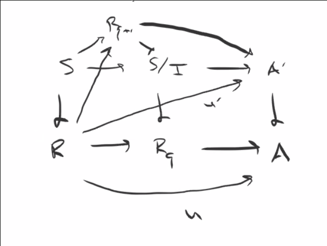

where the diagonal map $u'$ gives us the desired lift, and thus

[figure not shown]

exists. This concludes showing miniversality.

## 14.2 Part of Proof

To finish, we want to show that H4 implies that the map on sections $h_R \xrightarrow{\xi} F$ is bijective.

[figure not shown]

where the map $\xi$ is “formal etale,” which will necessarily imply that it’s a bijection over all artinian rings. So we just need to show formal étaleness. We have a diagram

[figure not shown]

where $u'$ exists by smoothness.

Assume that are two $u', u''$, then $u' = u'' + \theta$ and $\operatorname{im}(u') = \operatorname{im}(u'') + \theta \implies \theta = 0$ and thus $u' = u''$.

## 14.3 Revisiting Goals

We originally had two goals:

1. Given a representable moduli functor (such as the Hilbert functor), we wanted to understand the local structure by analyzing the deformation functor at a given point.
2. We want to use representability of the deformation functors to get global representability of the original functor.

What can we now deduce about the local structure of functors using their deformation theory?

Any two hulls $h_R \to F$ are isomorphic but not canonically. We can lift maps at every finite level and induct up, which is an isomorphism on tangent spaces and thus an isomorphism. The sketch: use smoothness to get the map, and the tangent space condition will imply the full isomorphism.

Suppose that $F$ has an obstruction theory (not necessarily strong). This implies there exists a hull $h_R \xrightarrow{\xi }F$. The obstruction theory of $F$ *gives* an obstruction theory of $h_R$: given $A' \to A$ a small thickening, we need a functorial assignment
$$\begin{align*}
t_R = \mathrm{def} {\circlearrowleft}h_R(A') \to h_R(A) \xrightarrow{\mathrm{obs}} \mathrm{obs} \\
\mathrm{def} {\circlearrowleft}F(A') \to F(A) \xrightarrow{\mathrm{obs}} \mathrm{obs}
\end{align*}
where there are vertical maps with equality on the edges.$$

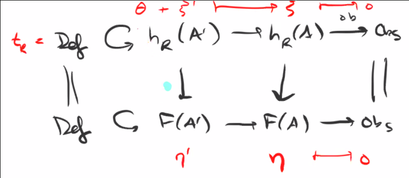

Vertical maps

By formal smoothness, $\eta'$ lifts to some $\xi'$, but using the transitivity of the action of the tangent space can fix this. We already had an obstruction theory of $R$, since we can always find a quotient
$$\begin{align*}
I \to S = k[[t_R^\vee]] \twoheadrightarrow R
\end{align*}
and \(h_K\) has an obstruction theory$$

- $\mathrm{def} = t_R = \qty{{\mathfrak{m}}_R/{\mathfrak{m}}_R^2}^\vee$
- $\mathrm{obs} = \qty{I/{\mathfrak{m}}_S I}^\vee$

Any other obstruction theory $(\mathrm{def}', \mathrm{obs}')$ of $h_R$ admits an injection $\qty{I/{\mathfrak{m}}_S I}^\vee\hookrightarrow\mathrm{obs}'$.

Combining these three facts, we conclude the following: If $F$ has an obstruction theory $\mathrm{def}(F), \mathrm{obs}(F)$, then $F$ has a miniversal family $h_R \xrightarrow{\xi }F$ with $R = S/ I$ a quotient of the formal power series ring over some ideal, where $S = k[[t_F^\vee]]$. It follows that $\dim(I/{\mathfrak{m}}_S I) \leq \dim \mathrm{obs}(F)$, and thus the minimal number of generators of $I$ (equal to the LHS by Nakayama) is bounded by the RHS. Thus
$$\begin{align*}
\dim_k \mathrm{def}(F) \geq \dim R \geq \dim \mathrm{def}(F) - \dim \mathrm{obs}(F)
.\end{align*}$$

In particular, if $\dim(R) = \dim \mathrm{def}(F) - \dim \mathrm{obs}(F)$, then $R$ is a complete intersection. If $\dim(R) = \dim \mathrm{def}(R)$, the ideal doesn’t have any generators, and $R \cong S$. In particular, if $\mathrm{obs}(F) = 0$, then $R \cong S$ is isomorphic to this power series ring.

Finally, if $F$ is the deformation functor for a global representable functor, then $R = \widehat{{\mathcal{O}}}_{{\mathfrak{m}}, p}$ is the completion of this local ring and the same things hold for this completion. Thus regularity can be checked on the completion. So if you have a representable functor with an obstruction theory (e.g. the Hilbert Scheme) with zero obstruction, then we have smoothness at that point. If we know something about the dimension at a point relative to the obstruction, we can deduce information about being a local intersection. So the deformation tells you the dimension of a minimal smooth embedding, and the obstruction is the maximal number of equations needed to cut it out locally.

The content here: see Hartshorne’s *Deformation Theory*. The section in FGA is in less generality but has many good examples. See “Fundamental Algebraic Geometry.” See also representability of the Picard scheme.

# 15 Thursday April 9th

Let $F: \operatorname{Art}_{/k} \to {\operatorname{Set}}$ be a deformation functor with an obstruction theory. Then H1-H3 imply the existence of a miniversal family, and gives us some control on the hull $h_{R} \to F$, namely
$$\begin{align*}
\dim \mathrm{def}(F) \geq \dim R \geq \dim \mathrm{def}(F) - \dim \mathrm{obs}(F)
.\end{align*}
In particular, if \(\mathrm{obs}(F) = 0\), then \(R \cong k[[\mathrm{def}(F)^\vee]] = k[[ t_{F}^\vee]]\).$$

Let $M = \operatorname{Hilb}_{{\mathbb{P}}^n_{/k}}^{dt + (1-g)}$ where $k=\mkern 1.5mu\overline{\mkern-1.5muk\mkern-1.5mu}\mkern 1.5mu$, and suppose $[Z] \in M$ is a smooth point. Then
$$\begin{align*}
\mathrm{def} = \hom_{ {{ {\mathcal{O}}_{x} }{\hbox{-}}\operatorname{mod}} }(I_{Z}, {\mathcal{O}}_{Z}) = \hom_{Z}(I_{Z}/I_{Z}^2, {\mathcal{O}}_{Z}) = H^0(N_{Z/X})
.\end{align*}
the normal bundle \(N_{Z/X} = (I/I^2)^\vee\) of the regular embedding, and \(\mathrm{obs} = H^1(N_{Z/X})\).$$

If $H^1({\mathcal{O}}_{Z}(1)) = 0$ (e.g. if $d > 2g-2)$ then $M$ is smooth.

The tangent bundle of ${\mathbb{P}}^n$ sits in the Euler sequence
$$\begin{align*}
0 \to {\mathcal{O}}\to {\mathcal{O}}(1)^{n+1} \to T_{{\mathbb{P}}^n} \to 0
.\end{align*}$$

And the normal bundles satisfies
$$\begin{align*}
0 \to T_{Z} &\to T_{{\mathbb{P}}^n}\mathrel{\Big|}_{Z} \to N_{Z/{\mathbb{P}}^n} \to 0 \\ \\
&\Downarrow \text{ is the dual of }\\ \\
0 \to I/I^2 &\to \Omega \mathrel{\Big|}_{Z} \to \Omega \to 0
.\end{align*}$$

This is one of the key outputs of obstruction theory: being able to compute these dimensions.

Let $X \subset {\mathbb{P}}^5$ be a smooth cubic hypersurface and let $H = \operatorname{Hilb}_{X_{/k}}^{\text{lines} = t+1} \subset \operatorname{Hilb}_{{\mathbb{P}}^5/k}^{t+1} = {\operatorname{Gr}}(1, {\mathbb{P}}^5)$, the usual Grassmannian.

Let $[\ell] \in H$, then the claim is that $H$ is smooth at $[\ell]$ of dimension 4.

We have

- $\mathrm{def} = H^0(N_{\ell/X})$
- $\mathrm{obs} = H^1(N_{\ell/X})$

We have an exact sequence
$$\begin{align*}
0 \to N_{\ell/X} \to N_{\ell/{\mathbb{P}}} \to N_{X/{\mathbb{P}}}\mathrel{\Big|}_\ell \to 0 \\
.\end{align*}$$

There are surjections from ${\mathcal{O}}_\ell(1)^6$ onto the last two terms.

For $N = N_{\ell/{\mathbb{P}}}$ or $N_{X/{\mathbb{P}}}\mathrel{\Big|}_\ell$, we have $H^1(N) = 0$ and ${\mathcal{O}}(1)^6 \twoheadrightarrow N$ is surjective on global sections.

Because $\ell$ is a line, ${\mathcal{O}}_\ell(1) = {\mathcal{O}}(1)$ and $H^1({\mathcal{O}}_\ell(1)) = 0$ and the previous proof applies, so $H^1(N) = 0$.

We thus have a diagram:

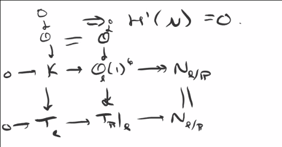

Image

In particular, $T_\ell = {\mathcal{O}}(2)$, and the LES for $0 \to {\mathcal{O}}\to K \to T_\ell$ shows $H^1(K) = 0$. Looking at the horizontal SES $0 \to K \to {\mathcal{O}}_\ell(1)^6 \twoheadrightarrow N_{\ell/{\mathbb{P}}}$ yields the surjection claim. We have

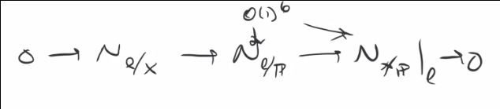

Diagram

and taking the LES in cohomology yields

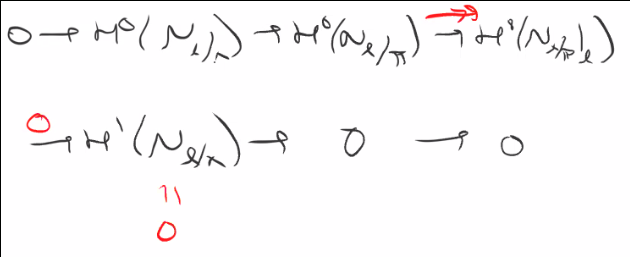

Therefore $H$ is smooth at $\ell$ and
$$\begin{align*}
\dim_\ell H
&= \chi(N_{\ell/X}) \\
&= \deg T_{X} - \deg T_\ell + 3 \\
&= \deg T_{\mathbb{P}}- \deg N_{X/{\mathbb{P}}} - \deg T_\ell + 3 \\
&= 6 - 3 - 2 + 3 = 4
.\end{align*}$$

It turns out that the Hilbert scheme of lines on a cubic has some geometry: the Hilbert scheme of two points on a K3 surface.

## 15.1 Abstract Deformations Revisited

Take $X_{0} / k$ some scheme and consider the deformation functor $F(A)$ taking $A$ to $X/A$ flat with an embedding $\iota: X_{0} \hookrightarrow X$ with $\iota \otimes k$ an isomorphism. Start with H1, the gluing axiom (regarding small thickenings $A' \to A$ and a thickening $A'' \to A$). Suppose
$$\begin{align*}
X_{0} \hookrightarrow X' \in F(A') \to F(A)
.\end{align*}
which restricts to \(X_{0} \hookrightarrow X\). Then in \(F(A)\), we have \(X_{0} \hookrightarrow X' \otimes_{A'} A\), and we obtain a commutative diagram where \(X' \otimes A \hookrightarrow X'\) is a closed immersion:$$

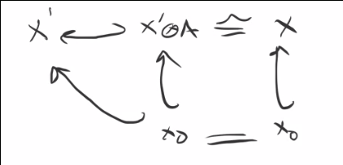

???

The restriction $X' \to X$ means that there exists a diagram

[figure not shown]

Note that this is not necessarily unique. We have

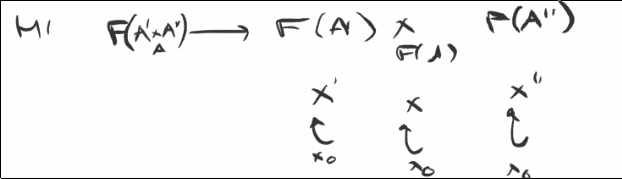

Diagram?

This means that we can find embeddings such that

[figure not shown]

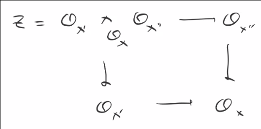

Diagram

And thus if we have

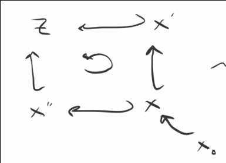

Diagram

then $X_{0} \hookrightarrow Z$ is **a** required lift (again not unique).

When is such a lift unique?

Suppose $X_{0} \hookrightarrow W$ is another lift, then it restricts to both $X, X'$ and we can fill in the following diagrams:

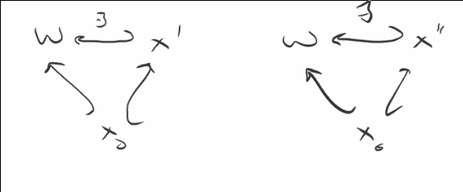

Diagram

Using the universal property of $Z$, which is the coproduct of this diagram:

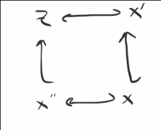

Diagram

However, there may be no such way to fill in the following diagram:

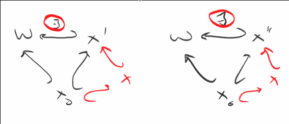

Diagram

But if there exists a map making this diagram commute:

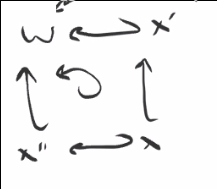

Diagram

Then there is a map $Z\to W$ which is flat after tensoring with $k$, which is thus an isomorphism.[^7]

Thus the lift is unique if

- $X = X_{0}$, then the following diagrams commute by taking the identity and the embedding you have. Note that in particular, this implies H2.

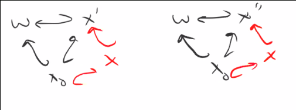

  Diagram

- Generally, these diagrams can be completed (and thus the gluing maps are bijective) if the map
  $$\begin{align*}
  \operatorname{Aut}(X_{0}\hookrightarrow X') \to \operatorname{Aut}(X_{0} \hookrightarrow X)
  .\end{align*}
  of automorphisms of \(X'\) commuting with \(X_{0} \hookrightarrow X\) is surjective.$$

So in this situation, there is only *one* way to fill in this diagram up to isomorphism:

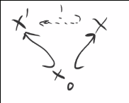

Diagram

If we had two ways of filling it in, we obtain bridging maps:

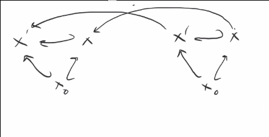

Diagram

If $H^0(X_{0}, T_{X_{0}}) = 0$ (where the tangent bundle always makes sense as the dual of the sheaf of Kahler differentials) which we can identify as derivations $D_{{\mathcal{O}}_{k}}({\mathcal{O}}_{X_{0}}, {\mathcal{O}}_{X_{0}})$, then the gluing map is bijective.

The claim is that $\operatorname{Aut}(X_{0} \hookrightarrow X) = 1$ are always trivial. This would imply that all random choices lead to triangles that commute. Proceeding by induction, for the base case $\operatorname{Aut}(X_{0} \hookrightarrow X_{0}) = 1$ trivially. Assume $X_{0} \hookrightarrow X_{i}$ lifts $X_{0} \hookrightarrow X$, then there’s an exact sequence
$$\begin{align*}
0
\to
\operatorname{Der}_{k}({\mathcal{O}}_{X_{0}}, {\mathcal{O}}_{X_{0}})
\to
{\operatorname{Aut}}(X_{0} \hookrightarrow X_0')
\to
{\operatorname{Aut}}(X_{0} \hookrightarrow X)
.\end{align*}$$

Thus $F$ always satisfies H1 and H2, and $H^0(T_{X_{0}}) = 0$ (so no “infinitesimal automorphism”) implies H4. Recall that the dimension of deformations of $F$ over $k[\varepsilon]$ is finite, i.e. $\dim t_{F} < \infty$ This is where some assumptions are needed.

If $X_{/K}$ is either

- Projective, or
- Affine with isolated singularities,

this is enough to imply H3. Thus by Schlessinger, under these conditions $F$ has a miniversal family.

Moreover, if $H^0(T_{X_{0}}) = 0$ then $F$ is pro-representable.

If $X_{0}$ is a smooth projective genus $g\geq 2$ curve, then

- Obstruction theory gives the existence of a miniversal family
- We have $\mathrm{obs} = H^2(T_{X_{0}}) = 0$, and thus the base of the miniversal family is smooth of dimension $\mathrm{def}(F) \dim H^1(T_{X_{0}})$,
- $H^0(T_{X_{0}}) = 0$ and $\deg T_{X_{0}} = 2-2g < 0$, which implies that the miniversal family is universal.

We can conclude
$$\begin{align*}
\dim H^1(T_{X_{0}}) = -\chi(T_{X_{0}}) = -\deg T_{X_{0}} + g-1 = 3(g-1)
.\end{align*}$$

Note that the global deformation functor is not representable by a scheme, and instead requires a stack. However, the same fact shows smoothness in that setting.

## 15.2 Hypersurface Singularities

Consider $X(f) \subset {\mathbb{A}}^n$, and for simplicity, $(f=0) \subset {\mathbb{A}}^2$, and let

- $S = {\mathbb{C}}[x, y]$.
- $B = {\mathbb{C}}[x, y] / (f)$

What are the deformations over $A \mathrel{\vcenter{:}}= k[\varepsilon]$?

This means we have a ring $B'$ flat over $k$ and tensors to an isomorphism, so tensoring $k\to A\to k$ yields the following:

[figure not shown]

Thus any such $B'$ is the quotient of $S[\varepsilon]$ by an ideal, and we have $f' = f + \varepsilon g$.

When do two $f'$s give the same $B'$?

We have $\varepsilon f' = \varepsilon f$, so $\varepsilon f \in (f')$ and we can modify $g$ by any $cf$ where $c\in S$, where only the equivalence class $g\in S/(f)$ matters. Now consider $\operatorname{Aut}(B \hookrightarrow B')$, i.e. maps of the form
$$\begin{align*}
x &\mapsto x + \varepsilon a \\
y &\mapsto y + cb
\end{align*}
for \(a, b\in S\). Under this map,
\begin{align*}
f_0'
= f + \varepsilon g \mapsto & f(x + \varepsilon a, y + \varepsilon b) + \varepsilon g(x ,y) \\ \\
&\Downarrow \quad\text{implies} \\ \\
f(x, y) &= \varepsilon a {\frac{\partial }{\partial x}\,} f + \varepsilon b {\frac{\partial }{\partial y}\,} f + \varepsilon g(x ,y)
,\end{align*}
so in fact only the class of \(g\in S/(f, {\partial}_{x} f, {\partial}_{y} f)\). This is the ideal of the singular locus, and will be Artinian (and thus finite-dimensional) if the singularities are isolated, which implies H3. We can in fact exhibit the miniversal family explicitly by taking \(g_{i} \in S\), yielding a basis of the above quotient. The hull will be given by setting \(R = {\mathbb{C}}[[t_{1}, \cdots, t_{m} ]]\) and taking the locus \(V(f + \sum t_{i} g_{i}) \subset {\mathbb{A}}_{R}^2\).$$

For $f = xy$, then the ideal is $I = (xy, y, x) = (x, y)$ and $C/I$ is 1-dimensional, so the miniversal family is given by $V(xy + t) \subset {\mathbb{C}}[[t_{1}]][x, y]$. The greater generality is needed because there are deformation functors with a hull but no universal families.

# 16 Tuesday April 14th

Recall that we are looking at $(X_{0})_{/k}$ and $F: \operatorname{Art}_{/k} \to {\operatorname{Set}}$ where $A$ is sent to $X_{/A}$ flat with $i: X_{0} \hookrightarrow X$ where $i\otimes k$ is an isomorphism. The second condition is equivalent to a cartesian diagram

[figure not shown]

We showed we always have H1 and H2, and H3 if $X_{0}/k$ is projective or $X_{0}$ is affine with isolated singularities. In this situation we have a miniversal family. This occurs iff for $A' \to A$ a small thickening and $(X_{0} \hookrightarrow X) \in F(A)$, we have a surjection
$$\begin{align*}
{\operatorname{Aut}}_{A'}(X_{0} \hookrightarrow X') \twoheadrightarrow{\operatorname{Aut}}_{A}(X_{0} \hookrightarrow X)
.\end{align*}$$

where the RHS are automorphisms of $X_{/A}$, i.e. those which commute with the identity on $A$ and $X_{0}$. We had a naive functor $F_{n}$ where we don’t include the inclusion $X_{0} \hookrightarrow X$. When $F$ has a hull then the naive functor has a versal family, since there is a forgetful map that is formally smooth. If it’s the case that for all $A' \to A$ small and $F_{\text{n}} \to F_{n}(A)$ we have ${\operatorname{Aut}}_{A'}(X') \twoheadrightarrow{\operatorname{Aut}}_{A} (X)$, then $F = F_{n}$ and both are pro-representable. The forgetful map is smooth because given $X_{/A}$ in $F_{n}(A)$, we have some inclusion $X_{0} \hookrightarrow X$, so one gives surjectivity. Using the surjectivity on automorphisms, we get

[figure not shown]

Deformation theory is better at answering when the following diagrams exist:

[figure not shown]

i.e., the existence of an extension of $X$ to $A'$. This is different than understanding diagrams of the following type, where we’re considering isomorphism classes of the squares, and deformation theory helps understand the blue one:

[figure not shown]

Take $S = k[x, y]$ and $B = S/(f)$, then deformations of $\operatorname{Spec}B$ to ? Given $k \to k[\varepsilon] \to k$ we can tensor[^8] to obtain

[figure not shown]

> Link to diagram.

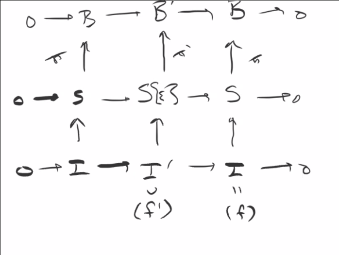

Diagram

We want to understand $F(k[\varepsilon])$. We know $f' = f + \varepsilon g$ for some $g\in S$.

1. $g\in B$ and $f'' = f + \varepsilon(g + cf)$ generates the same ideal.
2. We’re free to reparameterize, i.e. $x \mapsto x + \varepsilon a$ and $y \mapsto y + \varepsilon b$ and thus
   $$\begin{align*}
   g \mapsto g + a f_{x} + b f_{y}
   \end{align*}
   , i.e. the partial derivatives.$$

Thus isomorphism classes of $B'$ in deformations $B' \to B$ only depend on the isomorphism classes $g\in B/(f_{x}, f_{y}) B$. When the singularities are isolated, this quotient is finite-dimensional as a $k{\hbox{-}}$vector space.

$F(k[\varepsilon]) = B/(f_{x}, f_{y})B$. Thus H3 holds and there is a miniversal family $h_{R} \to F$. We can describe it explicitly: take $g_{i} \in S$, yielding a $k{\hbox{-}}$basis in $S/(f, f_{x}, f_{y})$. Then
$$\begin{align*}
V(f + \sum t_{i} g_{i}) \subset \operatorname{Spec}k[[t_{1}, \cdots, t_{n}]][x, y]
.\end{align*}
Set \(R = k[[t_{1}, \cdots, t_{n}]]\), then this lands in \({\mathbb{A}}_{R}^2\).$$

Note that none of these are pro-representable.

Given $X$ and $A$, we obtain a miniversal family over the formal spectrum $\mathrm{Spf}(R) = (R, \xi)$ and a unique map:

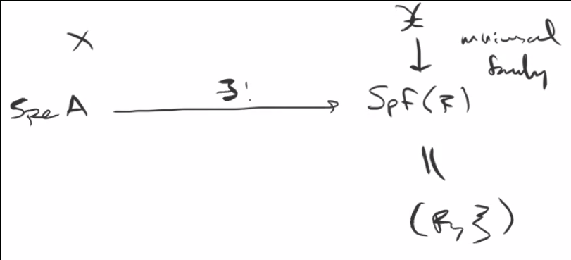

Diagram

We can take two deformations over $A = k[\xi]/ S^n$:

- $X_{1} = V(x + y)$??
- $X_{2} = V(x + uy)$??

As deformations over $A$, $X_{1} \cong X_{2}$ where we send ,
$$\begin{align*}
s&\mapsto s, \\
y&\mapsto y, \\
x&\mapsto ux
.\end{align*}
since
\begin{align*}
(xy + us) = (uxy + us) = (u(xy + s)) = (xy + s)
.\end{align*}
But we have two different classifying maps, which do commute up to an automorphism of \(A\), but are not equal. Since they pullback to different elements (?), \(F\) can not be pro-representable.$$

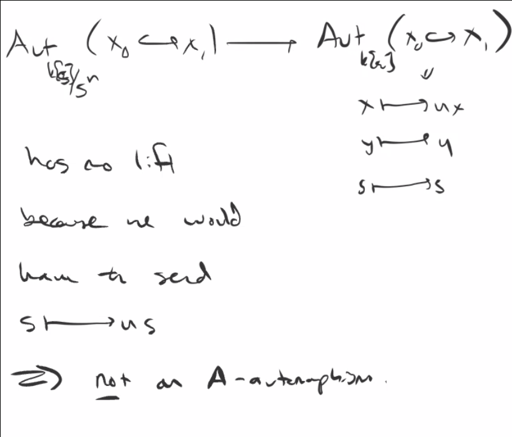

Diagram

So reparameterization in $A$ yield different objects in $F(A)$. In other words, ${\mathcal{X}}\to \mathrm{Spf}(R)$ has automorphisms inducing reparameterizations of $R$. This indicates why we need maps restricting to the identity.